# Appendix S1

A comparison of methods for estimating the health effects of exposures over the life course: adiposity and systemic inflammation in the 1958 National Child Development Study

```r
library(here)
library(gtsummary)
library(gt)
library(mgcv)
library(tidygam)
library(lcmm)
library(marginaleffects)
source(here("Code", "Clean_NCDS.R"))
source(here("Code", "IOTF_BMI.R"))
set_gtsummary_theme(theme_gtsummary_compact(set_theme = TRUE))
```

```r
# Load the fitted Hierarchical GAM model for BMI predictions
mod.BMI.fs.bam <- readRDS(here("Data", "Models", "mod.BMI.fs.bam.rds"))

# Create predictions from Hierarchical GAM model
df.bmi_prediction <- expand.grid(
  xage = 7:56,
  self_report = 0,
  ncdsid = unique(df.NCDS.HBMI.complete.analytic$ncdsid)) %>%
  left_join(
    df.NCDS.HBMI.complete.analytic %>%
    select(ncdsid, sex) %>%
    filter(!is.na(sex)) %>%
    distinct() %>%
    group_by(ncdsid) %>%
    summarise(sex = first(sex), .groups = "drop"),
  by = "ncdsid"
  ) %>%
  mutate(
    pred_bmi = predict(mod.BMI.fs.bam, newdata = ., type = "response")
  ) %>%
  mutate(sex = ifelse(sex == "Female", "F", "M")) %>%
  left_join(iotf_cutoffs, by = c("sex", "xage" = "age")) %>%
  mutate(
    bmi_category = case_when(
      pred_bmi < 25   ~ "Normal",
      xage >= 18 & pred_bmi < 30   ~ "Overweight",
      xage >= 18                   ~ "Obese",
      xage < 18 & pred_bmi < overweight  ~ "Normal",
      xage < 18 & pred_bmi < obese       ~ "Overweight",
      xage < 18                          ~ "Obese",
      TRUE ~ NA_character_
    )
  )
```

# 1 Analytic Sample

This section describes the derivation of the analytic sample from the NCDS Wave 10 interview cohort and provides descriptive statistics for all variables used in subsequent analyses. Figure S 1 presents the sample flow diagram, detailing each exclusion criterion applied from initial Wave 10 participation through nurse visit consent, blood sample collection, valid hsCRP measurement, removal of values above 10 mg/L (indicating possible acute infection), completeness of early life covariates, and the requirement of at least three longitudinal BMI measurements. Table S 1 summarizes the distributions of the outcome (log-transformed hsCRP), BMI averaged across three life periods, and all covariates in the final analytic sample. Table S 2 reports the distribution of the number of BMI observations per respondent, reflecting the density of the longitudinal BMI data available for exposure modeling.

Figure S 1: Sample flow diagram showing the derivation of the analytic sample from the NCDS Wave 10 cohort.

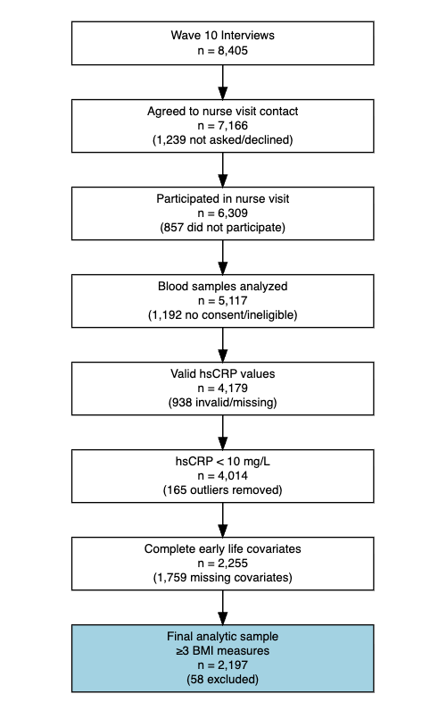

```r
library(DiagrammeR)
```

```r
df.bmi_prediction %>%
  group_by(ncdsid) %>%
  select(ncdsid, xage, pred_bmi) %>%
  summarise(
    mean_bmi_early_life = mean(pred_bmi[xage >= 7 & xage <= 25], na.rm = TRUE), # early life BMI (7-25 years)
    mean_bmi_early_midlife = mean(pred_bmi[xage > 25 & xage <= 40], na.rm = TRUE), # early midlife BMI (26-40 years)
    mean_bmi_late_midlife = mean(pred_bmi[xage > 40 & xage <= 60], na.rm = TRUE) # late midlife BMI (41-60 years)
  ) %>%
  right_join(df.model, by = "ncdsid") %>%
  select(loghsCRP, starts_with("mean_bmi"), all_of(covs)) %>%
  filter(complete.cases(.)) %>%
  tbl_summary(
    include = c(loghsCRP, sweep10_age, sex, mean_bmi_early_life, mean_bmi_early_midlife, mean_bmi_late_midlife, educ_qual, father_bmi, mother_bmi, n646, n607, n2383),
    statistic = list(
      all_continuous() ~ "{mean} ({sd})",
      all_categorical() ~ "{n} ({p}%)"
    ),
    label = list(
      loghsCRP ~ "log(hsCRP)",
      mean_bmi_early_life ~ "Mean BMI (7-25 years)",
      mean_bmi_early_midlife ~ "Mean BMI (26-40 years)",
      mean_bmi_late_midlife ~ "Mean BMI (41-56 years)",
      sex ~ "Sex",
      sweep10_age ~ "Age at hsCRP measurement (years)",
      educ_qual ~ "Educational qualification",
      father_bmi ~ "Father's BMI",
      mother_bmi ~ "Mother's BMI",
      n646 ~ "Birthweight",
      n607 ~ "Person's per room",
      n2383 ~ "Father's occupation"
    ),
    missing = "ifany",
    missing_text = "Missing"
  ) %>%
  italicize_levels() %>%
  modify_table_body(
    ~ .x %>%
      add_row(
        .before = which(.x$variable == "educ_qual"),
        label = "     Early Childhood Covariates",
        variable = NA,
        stat_0 = ""
      )
  )
```

Table S 1: Descriptive statistics for the analytic sample.

| **Characteristic** | **N = 2,197**<sup>1</sup> |
| --- | --- |
| log(hsCRP) | 0.20 (1.00) |
| Age at hsCRP measurement (years) | 64.88 (0.47) |
| Sex |  |
| Female | 1,094 (50%) |
| Male | 1,103 (50%) |
| Mean BMI (7-25 years) | 19.64 (1.96) |
| Mean BMI (26-40 years) | 24.51 (3.22) |
| Mean BMI (41-56 years) | 27.0 (4.3) |
| Early Childhood Covariates |  |
| Educational qualification |  |
| No Qualifications | 298 (14%) |
| GCSEs or Equivalent | 1,021 (46%) |
| A Levels or Equivalent | 216 (9.8%) |
| Degree or Higher | 662 (30%) |
| Father's BMI | 24.60 (3.00) |
| Mother's BMI | 23.7 (3.7) |
| Birthweight |  |
| Low | 66 (3.0%) |
| Normal | 1,120 (51%) |
| High | 1,011 (46%) |
| Person's per room |  |
| Up to 1 | 1,379 (63%) |
| Over 1 to 1.5 | 580 (26%) |
| Over 1.5 to 2 | 193 (8.8%) |
| Over 2 | 45 (2.0%) |
| Father's occupation |  |
| Employed | 2,024 (92%) |
| Unemployed, sick, retired, or other | 80 (3.6%) |
| No male present | 93 (4.2%) |

<sup>1</sup> Mean (SD); n (%)

```r
# Analyze the distribution of BMI measurements per respondent
df.NCDS.HBMI.complete.analytic %>%
    group_by(ncdsid) %>%
    summarise(n_visits = n()) %>%
    count(n_visits) %>%
    rename(`Number of BMI Observations` = n_visits,
           `Number of Respondents` = n) %>%
    mutate(`Percent` = round(100 * `Number of Respondents` / sum(`Number of Respondents`), 1)) %>%
    gt() %>%
    fmt_number(columns = `Number of Respondents`, decimals = 0) %>%
    cols_align(align = "center")
```

Table S 2: Distribution of the number of longitudinal BMI observations available per respondent in the analytic sample.

| Number of BMI Observations | Number of Respondents | Percent |
| --- | --- | --- |
| 3 | 5 | 0.2 |
| 4 | 27 | 1.2 |
| 5 | 40 | 1.8 |
| 6 | 119 | 5.4 |
| 7 | 302 | 13.7 |
| 8 | 622 | 28.3 |
| 9 | 1,082 | 49.2 |

BMI measures were drawn from a consolidated dataset (CLOSER Work Package 1) including harmonized height, weight, and BMI measures from the five British longitudinal cohort studies including the NCDS.<sup>1</sup> Childhood and adolescent BMI values (ages 7, 11, and 16) were derived from direct physical measurements taken by a nurse. Adult BMI values were obtained from a mix of self-reported and measured data, depending on wave: weight and height at ages 23, 42, and 50 were self-reported, while assessments at ages 33 and 44 were completed by trained interviewers or nurses. BMI at age 55 was derived from self-reported height and weight collected via web or telephone interview as part of the age 55 wave.<sup>2</sup>

# 2 Modeling BMI Exposure

The hierarchical GAM was implemented using the computationally efficient `bam()` function in the `mgcv` package in R.<sup>3,4</sup> Modeling BMI as a smooth trajectory is appropriate because the analysis targets longer-term patterns of adiposity rather than short-term fluctuations in weight between measurement occasions. Smoothing reduces noise due to irregular timing while preserving the broader exposure patterns. To ensure appropriate flexibility in exposure patterns, we estimated a separate non-linear BMI trajectory for each individual while constraining trajectories to share the same degree of smoothness (Model S structure)<sup>5</sup> (see Figure 1 in main text). The model also includes a fixed effect for measurement mode (directly measured vs. self-reported) to account for systematic reporting differences. This approach to imputation reduces noise due to irregular measurement timing, accounts for systematic reporting differences, and provides consistent longitudinal BMI trajectories for each respondent.

(a) Population-Level BMI Trajectory

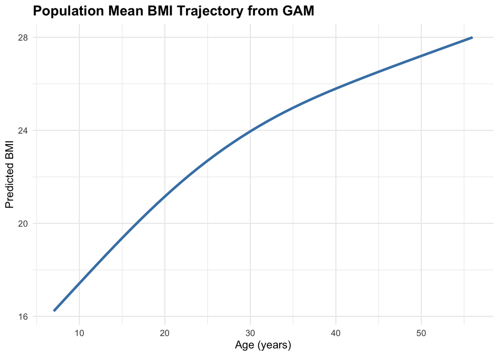

(b) Individual BMI Trajectories (Sample of 16)

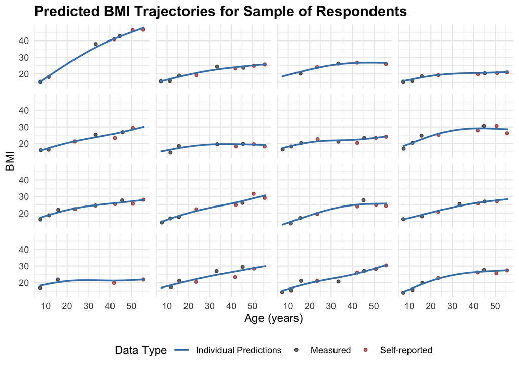

```r
# Create population-level prediction data by aggregating individual predictions
population_data <- df.bmi_prediction %>%
  group_by(xage) %>%
  summarise(
    pred_bmi = mean(pred_bmi, na.rm = TRUE),
    se_fit = sd(pred_bmi, na.rm = TRUE) / sqrt(n()),
    .groups = "drop"
  ) %>%
  mutate(
    lower_ci = pred_bmi - 1.96 * se_fit,
    upper_ci = pred_bmi + 1.96 * se_fit
  )

# Plot population-level BMI trajectory
population_data %>%
  ggplot(aes(x = xage, y = pred_bmi)) +
  geom_ribbon(aes(ymin = lower_ci, ymax = upper_ci), alpha = 0.6, fill = "lightgray") +
  geom_line(color = "steelblue", size = 1.2) +
  labs(x = "Age (years)",
       y = "Predicted BMI",
       title = "Population Mean BMI Trajectory from GAM") +
  theme_minimal() +
  theme(plot.title = element_text(face = "bold", size = 14))
set.seed(1234)  # For reproducibility

df.sampleplot <-
  df.NCDS.HBMI.complete.analytic %>%
  group_by(ncdsid) %>%
  nest() %>%
  ungroup() %>%
  slice_sample(n = 16) %>%  # Sample 25 random observations
  unnest()

# Plot the sampled 20 individuals
df.sampleplot %>%
  mutate(measurement_type = ifelse(self_report == 1, "Self-reported", "Measured")) %>%
  ggplot(aes(x = xage, y = bmi)) +
    # Scatter plot with measurement type in the aesthetic
    geom_point(aes(color = measurement_type), alpha = 0.6, size = 1.2) +
    # GAM model predictions for the same 16 individuals
    geom_line(data = df.bmi_prediction %>%
                filter(ncdsid %in% unique(df.sampleplot$ncdsid)),
              aes(x = xage, y = pred_bmi, color = "Individual Predictions"),
              size = 0.8) +
    facet_wrap(~ncdsid) +
    # Labels and Theme
    labs(x = "Age (years)", y = "BMI", color = "Data Type", title = "Predicted BMI Trajectories for Sample of Respondents") +
    scale_color_manual(values = c(
      "Measured" = "black",
      "Self-reported" = "darkred",
      "Individual Predictions" = "steelblue")) +
    theme_minimal() +
    theme(strip.text = element_blank(),  # Remove facet titles
          legend.position = "bottom",
          plot.title = element_text(face = "bold", size = 14))  # Move legend to the bottom
```

# 3 Lifecourse Methods Summary Table

Table S 3 provides a side-by-side comparison of all seven life course methods, summarizing the key estimand produced by each approach, the primary research question it addresses, and an example substantive conclusion drawn from the BMI–hsCRP analysis presented in this appendix.

Table S 3: Life Course Methods: Estimands, Research Questions, and Example Results

[output not shown]

# 4 Single Numeric Summaries

The single numeric summary approach reduces longitudinal exposure histories to a single scalar quantity intended to summarize exposure burden over a specified period. Depending on how the summary is defined (e.g., mean exposure, cumulative exposure, time above a threshold), this framework may reflect an accumulation-of-risk hypothesis (e.g., mean BMI) or a sensitive period hypothesis (if restricted to a specific window) in which exposure during that window is assumed to have specific influence over later-life outcomes. Here we use the mean BMI across ages 7-56 and include it as an exposure variable in a linear regression predicting log(hsCRP). This is the simplest life course method, treating all time points as equally informative and assuming that a single aggregate captures the relevant exposure signal. Table S 4 presents the fully adjusted regression results, including the effect of mean lifetime BMI on log(hsCRP) alongside all covariates.

```r
df.singlesummary <- df.bmi_prediction %>%
  group_by(ncdsid) %>%
  select(ncdsid, pred_bmi, bmi_category) %>%
  summarise(
    mean_bmi = mean(pred_bmi, na.rm = TRUE),
    yrs_normal      = sum(bmi_category == "Normal", na.rm = TRUE),
    yrs_overweight  = sum(bmi_category == "Overweight", na.rm = TRUE),
    yrs_obese       = sum(bmi_category == "Obese", na.rm = TRUE)
  ) %>%
  right_join(df.model, by = "ncdsid")


bmi_var <- "mean_bmi"
outcomes <- c("loghsCRP")

# Run single summary model
model.single <- map(outcomes, function(outcome) {
  all_covs <- c(bmi_var, covs)
  formula <- reformulate(all_covs, response = outcome)

  df.singlesummary %>%
    select(all_of(c(outcome, all_covs))) %>%
    lm(formula, data = .)
})

saveRDS(model.single, file = here("Data", "Models", "model.single.rds"))
```

```r
model.single %>%
  .[[1]] %>%
  tbl_regression(
    label = list(
      mean_bmi ~ "Mean BMI",
      sex ~ "Sex",
      sweep10_age ~ "Age at hsCRP measurement (years)",
      educ_qual ~ "Educational qualification",
      father_bmi ~ "Father's BMI",
      mother_bmi ~ "Mother's BMI",
      n646 ~ "Birthweight",
      n607 ~ "Person's per room",
      n2383 ~ "Father's occupation"
    )
  ) %>%
  add_significance_stars(hide_ci = FALSE) %>%
  bold_p() %>%
  bold_labels()
```

Table S 4: Adjusted linear regression of log(hsCRP) on mean lifetime BMI (ages 7–56), treating the entire trajectory as a single numeric summary.

| **Characteristic** | **Beta**<sup>1</sup> | **SE** | **95% CI** |
| --- | --- | --- | --- |
| Mean BMI | 0.09*** | 0.008 | 0.08, 0.11 |
| Sex |  |  |  |
| Female | — | — | — |
| Male | -0.21*** | 0.042 | -0.29, -0.12 |
| Age at hsCRP measurement (years) | 0.02 | 0.044 | -0.07, 0.10 |
| Educational qualification |  |  |  |
| No Qualifications | — | — | — |
| GCSEs or Equivalent | -0.19** | 0.064 | -0.32, -0.07 |
| A Levels or Equivalent | -0.23** | 0.087 | -0.40, -0.06 |
| Degree or Higher | -0.35*** | 0.069 | -0.48, -0.21 |
| Father's BMI | -0.01 | 0.007 | -0.03, 0.00 |
| Mother's BMI | 0.00 | 0.006 | -0.01, 0.01 |
| Birthweight |  |  |  |
| Low | — | — | — |
| Normal | -0.11 | 0.122 | -0.35, 0.13 |
| High | -0.18 | 0.122 | -0.42, 0.06 |
| Person's per room |  |  |  |
| Up to 1 | — | — | — |
| Over 1 to 1.5 | 0.04 | 0.048 | -0.06, 0.13 |
| Over 1.5 to 2 | 0.06 | 0.075 | -0.08, 0.21 |
| Over 2 | 0.21 | 0.147 | -0.08, 0.50 |
| Father's occupation |  |  |  |
| Employed | — | — | — |
| Unemployed, sick, retired, or other | -0.01 | 0.110 | -0.23, 0.20 |
| No male present | -0.01 | 0.102 | -0.21, 0.19 |

Abbreviations: CI = Confidence Interval, SE = Standard Error  
<sup>1</sup> *p<0.05; **p<0.01; ***p<0.001

# 5 Time Period Comparisons

Rather than collapsing exposure across the entire life span or a subset thereof, this approach partitions the life course into discrete windows intended to correspond to theoretically meaningful stages (e.g., childhood, adolescence, adulthood). Exposure within each period is aggregated using a summary statistic, and these period-specific summaries are included as predictors in regression models in separate models or included simultaneously in a single model. Conditional models estimate associations in each period conditional on exposure in other periods, allowing comparisons of relative importance across life stages. Because the conditioning set determines the contrast being estimated, interpretation depends on which life stages are included in the model.

Here the life course is divided into early life (ages 7–25), early midlife (ages 26–40), and late midlife (ages 41–56), and BMI exposure within each period is examined as a predictor of log(hsCRP). Two modeling strategies are presented. First, separate models fit one period-specific BMI measure at a time, allowing each period’s unconditional association with inflammation to be estimated independently (Table S 5 through Table S 8). Both continuous (mean BMI) and categorical (years spent in each BMI category) summaries are examined for each period. Second, conditional models enter BMI from multiple periods together, estimating each period’s contribution after adjusting for BMI at other life stages (Table S 9). The conditional approach uses a stepwise inclusion strategy with a first model that includes early life alone, then early life plus early midlife, then all three periods to assess how effect estimates attenuate as additional periods are conditioned upon.

```r
df.timeperiod <- df.bmi_prediction %>%
    group_by(ncdsid) %>%
    summarise(
      # Mean BMI by period
      mean_bmi_early_life = mean(pred_bmi[xage >= 7 & xage <= 25], na.rm = TRUE),
      mean_bmi_early_midlife = mean(pred_bmi[xage > 25 & xage <= 40], na.rm = TRUE),
      mean_bmi_late_midlife = mean(pred_bmi[xage > 40 & xage <= 60], na.rm = TRUE),

      # Years in each BMI category - Early life (7-25)
      yrs_normal_earlylife = sum(bmi_category == "Normal" & xage >= 7 & xage <= 25, na.rm = TRUE),
      yrs_overweight_earlylife = sum(bmi_category == "Overweight" & xage >= 7 & xage <= 25, na.rm = TRUE),
      yrs_obese_earlylife = sum(bmi_category == "Obese" & xage >= 7 & xage <= 25, na.rm = TRUE),

      # Years in each BMI category - Early midlife (25-40)
      yrs_normal_early_midlife = sum(bmi_category == "Normal" & xage > 25 & xage <= 40, na.rm = TRUE),
      yrs_overweight_early_midlife = sum(bmi_category == "Overweight" & xage > 25 & xage <= 40, na.rm = TRUE),
      yrs_obese_early_midlife = sum(bmi_category == "Obese" & xage > 25 & xage <= 40, na.rm = TRUE),

      # Years in each BMI category - Late midlife (41-60)
      yrs_normal_late_midlife = sum(bmi_category == "Normal" & xage > 40 & xage <= 60, na.rm = TRUE),
      yrs_overweight_late_midlife = sum(bmi_category == "Overweight" & xage > 40 & xage <= 60, na.rm = TRUE),
      yrs_obese_late_midlife = sum(bmi_category == "Obese" & xage > 40 & xage <= 60, na.rm = TRUE)
    ) %>%
    right_join(df.model, by = "ncdsid")

# Define the 6 BMI predictors to loop through
bmi_predictors <- c(
  "mean_bmi_early_life",
  "mean_bmi_early_midlife",
  "mean_bmi_late_midlife",
  "yrs_normal_earlylife",
  "yrs_overweight_earlylife",
  "yrs_obese_earlylife",
  "yrs_normal_early_midlife",
  "yrs_overweight_early_midlife",
  "yrs_obese_early_midlife",
  "yrs_normal_late_midlife",
  "yrs_overweight_late_midlife",
  "yrs_obese_late_midlife"
)

# Run separate time period models and store each model in a list
models_list.timeperiod <- map(bmi_predictors, function(bmi_var) {
    all_covs <- c(bmi_var, covs)
    formula <- reformulate(all_covs, response = "loghsCRP")

    df.timeperiod %>%
      select(all_of(c("loghsCRP", all_covs))) %>%
      rename(exposure = all_of(bmi_var)) %>%  # Rename to generic "exposure"
      lm(reformulate(c("exposure", covs), response = "loghsCRP"), data = .)
  })

saveRDS(models_list.timeperiod, file = here("Data", "Models", "models_list.timeperiod.rds"))
```

```r
cov_labels <- list(
  exposure ~ "BMI Exposure",
  sex ~ "Sex",
  sweep10_age ~ "Age at hsCRP measurement (years)",
  educ_qual ~ "Educational qualification",
  father_bmi ~ "Father's BMI",
  mother_bmi ~ "Mother's BMI",
  n646 ~ "Birthweight",
  n607 ~ "Persons per room",
  n2383 ~ "Father's occupation"
)

tbl_merge(
    tbls = map(models_list.timeperiod[1:3], ~ .x %>%
      tbl_regression(
        intercept = FALSE,
        label = cov_labels
      ) %>%
      add_significance_stars() %>%
      bold_p() %>%
      bold_labels()
    ),
    tab_spanner = c(
      "**Mean BMI <br> (7-25)**",
      "**Mean BMI <br> (26-40)**",
      "**Mean BMI <br> (41-56)**"
    )
  ) %>%
    modify_table_body(
      ~ .x %>%
        mutate(
          is_exposure = variable == "exposure",
          is_glance = row_type == "glance_statistic"
        ) %>%
        arrange(desc(is_exposure), is_glance) %>%
        select(-is_exposure, -is_glance)
    )
```

Table S 5: Separate adjusted regressions of log(hsCRP) on period-specific mean BMI.

| **Characteristic** | Mean BMI (7-25) **Beta**<sup>1</sup> | Mean BMI (7-25) **SE** | Mean BMI (26-40) **Beta**<sup>1</sup> | Mean BMI (26-40) **SE** | Mean BMI (41-56) **Beta**<sup>1</sup> | Mean BMI (41-56) **SE** |
| --- | --- | --- | --- | --- | --- | --- |
| BMI Exposure | 0.06*** | 0.012 | 0.07*** | 0.007 | 0.07*** | 0.005 |
| Sex |  |  |  |  |  |  |
| Female | — | — | — | — | — | — |
| Male | -0.15*** | 0.042 | -0.21*** | 0.042 | -0.23*** | 0.041 |
| Age at hsCRP measurement (years) | 0.01 | 0.045 | 0.01 | 0.044 | 0.02 | 0.043 |
| Educational qualification |  |  |  |  |  |  |
| No Qualifications | — | — | — | — | — | — |
| GCSEs or Equivalent | -0.20** | 0.065 | -0.19** | 0.064 | -0.19** | 0.063 |
| A Levels or Equivalent | -0.26** | 0.089 | -0.24** | 0.087 | -0.23** | 0.086 |
| Degree or Higher | -0.39*** | 0.070 | -0.36*** | 0.069 | -0.33*** | 0.068 |
| Father's BMI | -0.01 | 0.007 | -0.01 | 0.007 | -0.01 | 0.007 |
| Mother's BMI | 0.01* | 0.006 | 0.01 | 0.006 | 0.00 | 0.006 |
| Birthweight |  |  |  |  |  |  |
| Low | — | — | — | — | — | — |
| Normal | -0.10 | 0.125 | -0.11 | 0.123 | -0.13 | 0.120 |
| High | -0.17 | 0.125 | -0.17 | 0.123 | -0.19 | 0.121 |
| Persons per room |  |  |  |  |  |  |
| Up to 1 | — | — | — | — | — | — |
| Over 1 to 1.5 | 0.05 | 0.049 | 0.04 | 0.048 | 0.03 | 0.047 |
| Over 1.5 to 2 | 0.10 | 0.077 | 0.07 | 0.076 | 0.05 | 0.074 |
| Over 2 | 0.25 | 0.151 | 0.22 | 0.149 | 0.18 | 0.145 |
| Father's occupation |  |  |  |  |  |  |
| Employed | — | — | — | — | — | — |
| Unemployed, sick, retired, or other | 0.00 | 0.113 | -0.01 | 0.111 | -0.01 | 0.109 |
| No male present | 0.00 | 0.104 | -0.01 | 0.103 | 0.01 | 0.100 |

Abbreviations: CI = Confidence Interval, SE = Standard Error  
<sup>1</sup> *p<0.05; **p<0.01; ***p<0.001

```r
tbl_merge(
    tbls = map(models_list.timeperiod[4:6], ~ .x %>%
      tbl_regression(
        intercept = FALSE,
        label = cov_labels
      ) %>%
      add_significance_stars() %>%
      bold_p() %>%
      bold_labels()
    ),
    tab_spanner = c(
      "**Yrs Normal <br> (7-25)**",
      "**Yrs Overweight <br> (7-25)**",
      "**Yrs Obese <br> (7-25)**"
    )
  ) %>%
    modify_table_body(
      ~ .x %>%
        mutate(
          is_exposure = variable == "exposure",
          is_glance = row_type == "glance_statistic"
        ) %>%
        arrange(desc(is_exposure), is_glance) %>%
        select(-is_exposure, -is_glance)
    )
```

Table S 6: Separate adjusted regressions of log(hsCRP) on years in each BMI category during early life (ages 7-25).

| **Characteristic** | Yrs Normal (7-25) **Beta**<sup>1</sup> | Yrs Normal (7-25) **SE** | Yrs Overweight (7-25) **Beta**<sup>1</sup> | Yrs Overweight (7-25) **SE** | Yrs Obese (7-25) **Beta**<sup>1</sup> | Yrs Obese (7-25) **SE** |
| --- | --- | --- | --- | --- | --- | --- |
| BMI Exposure | -0.05*** | 0.009 | 0.05*** | 0.011 | 0.08*** | 0.023 |
| Sex |  |  |  |  |  |  |
| Female | — | — | — | — | — | — |
| Male | -0.15*** | 0.042 | -0.15*** | 0.042 | -0.15*** | 0.043 |
| Age at hsCRP measurement (years) | 0.01 | 0.045 | 0.01 | 0.045 | 0.01 | 0.045 |
| Educational qualification |  |  |  |  |  |  |
| No Qualifications | — | — | — | — | — | — |
| GCSEs or Equivalent | -0.19** | 0.065 | -0.19** | 0.065 | -0.19** | 0.066 |
| A Levels or Equivalent | -0.25** | 0.089 | -0.26** | 0.089 | -0.26** | 0.089 |
| Degree or Higher | -0.39*** | 0.070 | -0.39*** | 0.070 | -0.40*** | 0.070 |
| Father's BMI | 0.00 | 0.007 | 0.00 | 0.007 | 0.00 | 0.007 |
| Mother's BMI | 0.02** | 0.006 | 0.02** | 0.006 | 0.02** | 0.006 |
| Birthweight |  |  |  |  |  |  |
| Low | — | — | — | — | — | — |
| Normal | -0.09 | 0.125 | -0.10 | 0.125 | -0.09 | 0.125 |
| High | -0.15 | 0.125 | -0.16 | 0.126 | -0.14 | 0.126 |
| Persons per room |  |  |  |  |  |  |
| Up to 1 | — | — | — | — | — | — |
| Over 1 to 1.5 | 0.04 | 0.049 | 0.04 | 0.049 | 0.04 | 0.049 |
| Over 1.5 to 2 | 0.09 | 0.077 | 0.10 | 0.077 | 0.11 | 0.077 |
| Over 2 | 0.26 | 0.151 | 0.28 | 0.151 | 0.21 | 0.152 |
| Father's occupation |  |  |  |  |  |  |
| Employed | — | — | — | — | — | — |
| Unemployed, sick, retired, or other | 0.00 | 0.113 | 0.00 | 0.113 | 0.01 | 0.113 |
| No male present | 0.00 | 0.104 | 0.00 | 0.105 | 0.02 | 0.105 |

Abbreviations: CI = Confidence Interval, SE = Standard Error  
<sup>1</sup> *p<0.05; **p<0.01; ***p<0.001

```r
tbl_merge(
    tbls = map(models_list.timeperiod[7:9], ~ .x %>%
      tbl_regression(
        intercept = FALSE,
        label = cov_labels
      ) %>%
      add_significance_stars() %>%
      bold_p() %>%
      bold_labels()
    ),
    tab_spanner = c(
      "**Yrs Normal <br> (26-40)**",
      "**Yrs Overweight <br> (26-40)**",
      "**Yrs Obese <br> (26-40)**"
    )
  ) %>%
    modify_table_body(
      ~ .x %>%
        mutate(
          is_exposure = variable == "exposure",
          is_glance = row_type == "glance_statistic"
        ) %>%
        arrange(desc(is_exposure), is_glance) %>%
        select(-is_exposure, -is_glance)
    )
```

Table S 7: Separate adjusted regressions of log(hsCRP) on years in each BMI category during early midlife (ages 26-40).

| **Characteristic** | Yrs Normal (26-40) **Beta**<sup>1</sup> | Yrs Normal (26-40) **SE** | Yrs Overweight (26-40) **Beta**<sup>1</sup> | Yrs Overweight (26-40) **SE** | Yrs Obese (26-40) **Beta**<sup>1</sup> | Yrs Obese (26-40) **SE** |
| --- | --- | --- | --- | --- | --- | --- |
| BMI Exposure | -0.03*** | 0.004 | 0.02*** | 0.004 | 0.05*** | 0.007 |
| Sex |  |  |  |  |  |  |
| Female | — | — | — | — | — | — |
| Male | -0.21*** | 0.043 | -0.20*** | 0.043 | -0.14*** | 0.042 |
| Age at hsCRP measurement (years) | 0.00 | 0.044 | 0.00 | 0.045 | 0.01 | 0.045 |
| Educational qualification |  |  |  |  |  |  |
| No Qualifications | — | — | — | — | — | — |
| GCSEs or Equivalent | -0.20** | 0.065 | -0.20** | 0.065 | -0.19** | 0.065 |
| A Levels or Equivalent | -0.26** | 0.088 | -0.28** | 0.089 | -0.24** | 0.089 |
| Degree or Higher | -0.37*** | 0.070 | -0.39*** | 0.070 | -0.38*** | 0.070 |
| Father's BMI | -0.01 | 0.007 | 0.00 | 0.007 | 0.00 | 0.007 |
| Mother's BMI | 0.01 | 0.006 | 0.02** | 0.006 | 0.02** | 0.006 |
| Birthweight |  |  |  |  |  |  |
| Low | — | — | — | — | — | — |
| Normal | -0.11 | 0.124 | -0.10 | 0.125 | -0.11 | 0.124 |
| High | -0.17 | 0.125 | -0.16 | 0.126 | -0.17 | 0.125 |
| Persons per room |  |  |  |  |  |  |
| Up to 1 | — | — | — | — | — | — |
| Over 1 to 1.5 | 0.04 | 0.049 | 0.04 | 0.049 | 0.04 | 0.049 |
| Over 1.5 to 2 | 0.08 | 0.076 | 0.10 | 0.077 | 0.08 | 0.077 |
| Over 2 | 0.26 | 0.150 | 0.27 | 0.151 | 0.23 | 0.150 |
| Father's occupation |  |  |  |  |  |  |
| Employed | — | — | — | — | — | — |
| Unemployed, sick, retired, or other | 0.02 | 0.112 | 0.03 | 0.113 | -0.02 | 0.112 |
| No male present | -0.01 | 0.104 | 0.00 | 0.105 | 0.01 | 0.104 |

Abbreviations: CI = Confidence Interval, SE = Standard Error  
<sup>1</sup> *p<0.05; **p<0.01; ***p<0.001

```r
tbl_merge(
    tbls = map(models_list.timeperiod[10:12], ~ .x %>%
      tbl_regression(
        intercept = FALSE,
        label = cov_labels
      ) %>%
      add_significance_stars() %>%
      bold_p() %>%
      bold_labels()
    ),
    tab_spanner = c(
      "**Yrs Normal <br> (41-56)**",
      "**Yrs Overweight <br> (41-56)**",
      "**Yrs Obese <br> (41-56)**"
    )
  ) %>%
    modify_table_body(
      ~ .x %>%
        mutate(
          is_exposure = variable == "exposure",
          is_glance = row_type == "glance_statistic"
        ) %>%
        arrange(desc(is_exposure), is_glance) %>%
        select(-is_exposure, -is_glance)
    )
```

Table S 8: Separate adjusted regressions of log(hsCRP) on years in each BMI category during late midlife (ages 41-56).

| **Characteristic** | Yrs Normal (41-56) **Beta**<sup>1</sup> | Yrs Normal (41-56) **SE** | Yrs Overweight (41-56) **Beta**<sup>1</sup> | Yrs Overweight (41-56) **SE** | Yrs Obese (41-56) **Beta**<sup>1</sup> | Yrs Obese (41-56) **SE** |
| --- | --- | --- | --- | --- | --- | --- |
| BMI Exposure | -0.04*** | 0.003 | 0.01** | 0.003 | 0.04*** | 0.004 |
| Sex |  |  |  |  |  |  |
| Female | — | — | — | — | — | — |
| Male | -0.27*** | 0.043 | -0.18*** | 0.044 | -0.16*** | 0.042 |
| Age at hsCRP measurement (years) | 0.01 | 0.044 | 0.01 | 0.045 | 0.00 | 0.044 |
| Educational qualification |  |  |  |  |  |  |
| No Qualifications | — | — | — | — | — | — |
| GCSEs or Equivalent | -0.21** | 0.064 | -0.21** | 0.066 | -0.18** | 0.064 |
| A Levels or Equivalent | -0.26** | 0.087 | -0.28** | 0.089 | -0.22* | 0.087 |
| Degree or Higher | -0.35*** | 0.069 | -0.41*** | 0.070 | -0.35*** | 0.069 |
| Father's BMI | -0.01 | 0.007 | 0.00 | 0.007 | 0.00 | 0.007 |
| Mother's BMI | 0.01 | 0.006 | 0.02*** | 0.006 | 0.01 | 0.006 |
| Birthweight |  |  |  |  |  |  |
| Low | — | — | — | — | — | — |
| Normal | -0.07 | 0.122 | -0.09 | 0.125 | -0.14 | 0.123 |
| High | -0.13 | 0.122 | -0.14 | 0.126 | -0.19 | 0.123 |
| Persons per room |  |  |  |  |  |  |
| Up to 1 | — | — | — | — | — | — |
| Over 1 to 1.5 | 0.02 | 0.048 | 0.04 | 0.049 | 0.04 | 0.048 |
| Over 1.5 to 2 | 0.06 | 0.075 | 0.10 | 0.077 | 0.09 | 0.075 |
| Over 2 | 0.22 | 0.147 | 0.26 | 0.152 | 0.20 | 0.149 |
| Father's occupation |  |  |  |  |  |  |
| Employed | — | — | — | — | — | — |
| Unemployed, sick, retired, or other | 0.04 | 0.110 | 0.02 | 0.113 | 0.02 | 0.111 |
| No male present | 0.00 | 0.102 | 0.02 | 0.105 | 0.02 | 0.103 |

Abbreviations: CI = Confidence Interval, SE = Standard Error  
<sup>1</sup> *p<0.05; **p<0.01; ***p<0.001

```r
# Define the 3 staggered BMI predictor combinations
bmi_predictor_sets <- list(
    "Early Life" = "mean_bmi_early_life",
    "Early + Early Midlife" = c("mean_bmi_early_life", "mean_bmi_early_midlife"),
    "All Three Periods" = c("mean_bmi_early_life", "mean_bmi_early_midlife", "mean_bmi_late_midlife")
  )

# Run conditional time period models and store each table in a list
models_list.timeperiod.staggered.conditional <- map(bmi_predictor_sets, function(bmi_vars) {
    all_covs <- c(bmi_vars, covs)
    formula <- reformulate(all_covs, response = "loghsCRP")

    df.timeperiod %>%
      select(all_of(c("loghsCRP", all_covs))) %>%
      lm(formula, data = .)
  })

saveRDS(models_list.timeperiod.staggered.conditional, file = here("Data", "Models", "models_list.timeperiod.conditional.rds"))
```

```r
cov_labels <- list(
  mean_bmi_early_life ~ "Mean BMI (7-25)",
  mean_bmi_early_midlife ~ "Mean BMI (26-40)",
  mean_bmi_late_midlife ~ "Mean BMI (41-56)",
  sex ~ "Sex",
  sweep10_age ~ "Age at hsCRP measurement (years)",
  educ_qual ~ "Educational qualification",
  father_bmi ~ "Father's BMI",
  mother_bmi ~ "Mother's BMI",
  n646 ~ "Birthweight",
  n607 ~ "Persons per room",
  n2383 ~ "Father's occupation"
)

tbl_merge(
    tbls = map2(models_list.timeperiod.staggered.conditional, bmi_predictor_sets, function(mod, bmi_vars) {
      # Filter labels to only include variables in this model
      model_vars <- c(bmi_vars, covs)
      model_labels <- cov_labels[sapply(cov_labels, function(x) as.character(x[[2]]) %in% model_vars)]

      mod %>%
        tbl_regression(
          intercept = FALSE,
          label = model_labels
        ) %>%
        add_significance_stars(hide_ci = FALSE) %>%
        bold_p() %>%
        bold_labels()
    }),
    tab_spanner = names(bmi_predictor_sets) %>% paste0("**", ., "**")
  ) %>%
    modify_table_body(
      ~ .x %>%
        mutate(
          is_bmi = variable %in% c("mean_bmi_early_life", "mean_bmi_early_midlife", "mean_bmi_late_midlife"),
          is_glance = row_type == "glance_statistic"
        ) %>%
        arrange(desc(is_bmi), is_glance) %>%
        select(-is_bmi, -is_glance)
    )
```

Table S 9: Conditional adjusted regressions of log(hsCRP) with mean BMI from multiple life periods entered jointly, using a stepwise inclusion strategy to assess conditional period-specific effects.

| **Characteristic** | **Early Life** **Beta**<sup>1</sup> | **Early Life** **SE** | **Early Life** **95% CI** | **Early + Early Midlife** **Beta**<sup>1</sup> | **Early + Early Midlife** **SE** | **Early + Early Midlife** **95% CI** | **All Three Periods** **Beta**<sup>1</sup> | **All Three Periods** **SE** | **All Three Periods** **95% CI** |
| --- | --- | --- | --- | --- | --- | --- | --- | --- | --- |
| Mean BMI (7-25) | 0.06*** | 0.012 | 0.04, 0.09 | -0.09*** | 0.019 | -0.12, -0.05 | 0.00 | 0.021 | -0.04, 0.04 |
| Mean BMI (26-40) |  |  |  | 0.11*** | 0.012 | 0.09, 0.14 | -0.07** | 0.022 | -0.12, -0.03 |
| Mean BMI (41-56) |  |  |  |  |  |  | 0.12*** | 0.012 | 0.09, 0.14 |
| Sex |  |  |  |  |  |  |  |  |  |
| Female | — | — | — | — | — | — | — | — | — |
| Male | -0.15*** | 0.042 | -0.24, -0.07 | -0.25*** | 0.043 | -0.33, -0.16 | -0.21*** | 0.042 | -0.30, -0.13 |
| Age at hsCRP measurement (years) | 0.01 | 0.045 | -0.08, 0.10 | 0.01 | 0.044 | -0.08, 0.10 | 0.02 | 0.043 | -0.06, 0.10 |
| Educational qualification |  |  |  |  |  |  |  |  |  |
| No Qualifications | — | — | — | — | — | — | — | — | — |
| GCSEs or Equivalent | -0.20** | 0.065 | -0.33, -0.07 | -0.19** | 0.064 | -0.31, -0.06 | -0.20** | 0.063 | -0.32, -0.07 |
| A Levels or Equivalent | -0.26** | 0.089 | -0.43, -0.08 | -0.24** | 0.087 | -0.41, -0.07 | -0.23** | 0.085 | -0.39, -0.06 |
| Degree or Higher | -0.39*** | 0.070 | -0.53, -0.26 | -0.34*** | 0.069 | -0.48, -0.21 | -0.33*** | 0.067 | -0.46, -0.20 |
| Father's BMI | -0.01 | 0.007 | -0.02, 0.01 | -0.01 | 0.007 | -0.02, 0.01 | -0.01 | 0.007 | -0.02, 0.01 |
| Mother's BMI | 0.01* | 0.006 | 0.00, 0.02 | 0.01 | 0.006 | 0.00, 0.02 | 0.01 | 0.006 | 0.00, 0.02 |
| Birthweight |  |  |  |  |  |  |  |  |  |
| Low | — | — | — | — | — | — | — | — | — |
| Normal | -0.10 | 0.125 | -0.34, 0.15 | -0.12 | 0.122 | -0.36, 0.12 | -0.14 | 0.119 | -0.37, 0.10 |
| High | -0.17 | 0.125 | -0.41, 0.08 | -0.17 | 0.123 | -0.41, 0.07 | -0.19 | 0.120 | -0.42, 0.05 |
| Persons per room |  |  |  |  |  |  |  |  |  |
| Up to 1 | — | — | — | — | — | — | — | — | — |
| Over 1 to 1.5 | 0.05 | 0.049 | -0.05, 0.14 | 0.03 | 0.048 | -0.06, 0.13 | 0.02 | 0.047 | -0.07, 0.12 |
| Over 1.5 to 2 | 0.10 | 0.077 | -0.05, 0.25 | 0.05 | 0.075 | -0.10, 0.20 | 0.05 | 0.074 | -0.10, 0.19 |
| Over 2 | 0.25 | 0.151 | -0.04, 0.55 | 0.20 | 0.148 | -0.09, 0.49 | 0.17 | 0.145 | -0.12, 0.45 |
| Father's occupation |  |  |  |  |  |  |  |  |  |
| Employed | — | — | — | — | — | — | — | — | — |
| Unemployed, sick, retired, or other | 0.00 | 0.113 | -0.22, 0.22 | -0.01 | 0.110 | -0.22, 0.21 | 0.00 | 0.108 | -0.21, 0.21 |
| No male present | 0.00 | 0.104 | -0.21, 0.20 | 0.00 | 0.102 | -0.20, 0.20 | 0.04 | 0.100 | -0.16, 0.23 |

Abbreviations: CI = Confidence Interval, SE = Standard Error  
<sup>1</sup> *p<0.05; **p<0.01; ***p<0.001

# 6 Multiple Informant Model Using General Estimating Equations

The multiple informant approach estimates associations between exposures at different life stages and a single outcome measure in a unified regression framework, treating synthetic copies of the outcome as repeated measures.<sup>6–8</sup> Estimation can be conducted using generalized estimating equations or maximum likelihood approaches.<sup>9,10</sup> Including the period indicators, BMI, and their interaction together quantifies differences in the exposure association across periods.

Here, the data are reshaped to long format, with each participant contributing three rows (one per period: early life, early midlife, and late midlife). The GEE model includes a period-by-BMI interaction term, enabling a formal test of whether the association between BMI and log(hsCRP) varies across life stages. An independence working correlation structure is specified, as the repeated measures here represent summary statistics from different life windows. Table S 10 reports the estimated main effects of BMI and period, the interaction terms, and all covariates. Linear hypothesis tests are conducted to compute the BMI–inflammation association in each period, with results presented in the main text.

```r
library(geepack)
library(geeM)

# Reshape the data to long format for GEE, keeping only necessary variables and ensuring complete cases for hsCRP and covariates
df.gee <- df.timeperiod %>%
  select(ncdsid, loghsCRP,
         mean_bmi_early_life,
         mean_bmi_early_midlife,
         mean_bmi_late_midlife,
         all_of(covs)) %>%
  drop_na(loghsCRP, all_of(covs)) %>%
  group_by(ncdsid) %>%
  nest() %>%
  ungroup() %>%
  unnest() %>%
  pivot_longer(
    cols = starts_with("mean_bmi"),
    names_to = "window",
    names_prefix = "mean_bmi_",
    values_to = "bmi"
  ) %>%
  mutate(
    ncdsid_numeric = as.numeric(factor(ncdsid))
  ) %>%
  relocate(ncdsid_numeric, .after = "ncdsid")

# Run the gee model
gee_model <- geeglm(
    loghsCRP ~ window * bmi + sex + sweep10_age + educ_qual + father_bmi + mother_bmi + n646 + n607 + n2383,
    id = ncdsid_numeric,
    data = df.gee,
    family = gaussian(),
    corstr = "independence"
  )

saveRDS(gee_model, file = here("Data", "Models", "gee_model.rds"))
```

```r
gee_labels <- list(
  window ~ "Period",
  bmi ~ "BMI",
  `window:bmi` ~ "Period × BMI",
  sex ~ "Sex",
  sweep10_age ~ "Age at hsCRP measurement (years)",
  educ_qual ~ "Educational qualification",
  father_bmi ~ "Father's BMI",
  mother_bmi ~ "Mother's BMI",
  n646 ~ "Birthweight",
  n607 ~ "Persons per room",
  n2383 ~ "Father's occupation"
)

gee_model %>%
  tbl_regression(
    label = gee_labels,
    include = c(window, bmi, `window:bmi`, sex, sweep10_age, educ_qual,
                father_bmi, mother_bmi, n646, n607, n2383)
  ) %>%
  add_significance_stars(hide_ci = FALSE) %>%
  bold_p() %>%
  bold_labels() %>%
  modify_table_styling(
    columns = label,
    rows = variable == "bmi",
    footnote = "Slope of log(hsCRP) on BMI in the reference period (early life, ages 7--25). The slopes for early midlife and late midlife are this coefficient plus the corresponding Period x BMI interaction; all three are reported in the main text."
  )
```

Table S 10: GEE regression of log(hsCRP) on period-specific BMI with a period-by-BMI interaction, testing whether the BMI–inflammation association differs across early life, early midlife, and late midlife.

| **Characteristic** | **Beta**<sup>1</sup> | **SE** | **95% CI** |
| --- | --- | --- | --- |
| Period |  |  |  |
| early_life | — | — | — |
| early_midlife | -0.37** | 0.123 | -0.61, -0.13 |
| late_midlife | -0.51** | 0.165 | -0.83, -0.18 |
| BMI<sup>2</sup> | 0.07*** | 0.011 | 0.05, 0.09 |
| Period × BMI |  |  |  |
| early_midlife * BMI | 0.00 | 0.007 | -0.01, 0.01 |
| late_midlife * BMI | 0.00 | 0.009 | -0.02, 0.02 |
| Sex |  |  |  |
| Female | — | — | — |
| Male | -0.20*** | 0.041 | -0.28, -0.12 |
| Age at hsCRP measurement (years) | 0.01 | 0.043 | -0.07, 0.10 |
| Educational qualification |  |  |  |
| No Qualifications | — | — | — |
| GCSEs or Equivalent | -0.19** | 0.062 | -0.32, -0.07 |
| A Levels or Equivalent | -0.24** | 0.083 | -0.40, -0.08 |
| Degree or Higher | -0.36*** | 0.068 | -0.49, -0.23 |
| Father's BMI | -0.01 | 0.007 | -0.02, 0.00 |
| Mother's BMI | 0.01 | 0.006 | 0.00, 0.02 |
| Birthweight |  |  |  |
| Low | — | — | — |
| Normal | -0.11 | 0.113 | -0.33, 0.11 |
| High | -0.17 | 0.113 | -0.40, 0.05 |
| Persons per room |  |  |  |
| Up to 1 | — | — | — |
| Over 1 to 1.5 | 0.04 | 0.048 | -0.05, 0.13 |
| Over 1.5 to 2 | 0.07 | 0.071 | -0.07, 0.21 |
| Over 2 | 0.22 | 0.128 | -0.03, 0.47 |
| Father's occupation |  |  |  |
| Employed | — | — | — |
| Unemployed, sick, retired, or other | -0.01 | 0.106 | -0.21, 0.20 |
| No male present | 0.00 | 0.100 | -0.20, 0.19 |

Abbreviations: CI = Confidence Interval, SE = Standard Error  
<sup>1</sup> *p<0.05; **p<0.01; ***p<0.001  
<sup>2</sup> Slope of log(hsCRP) on BMI in the reference period (early life, ages 7–25). The slopes for early midlife and late midlife are this coefficient plus the corresponding Period x BMI interaction; all three are reported in the main text.

# 7 Sequence Analysis

Sequence analysis represents life course exposure as an ordered series of categorical states and groups individuals based on similarities in these state sequences using distance metrics and clustering algorithms.<sup>11,12</sup> The resulting sequence clusters can then be used as categorical predictors in regression models to estimate differences in outcomes across trajectory patterns. Pairwise dissimilarities between sequences were computed using optimal matching, and Ward’s hierarchical clustering was applied to the resulting distance matrix to identify groups of individuals with similar BMI state trajectories. Analyses were conducted using the `TraMineR` and `cluster` packages in R.<sup>13</sup> Because the sequences are built from the HGAM-predicted BMI at every age, they contain no missing states; missingness in the observed BMI measurements is handled at the imputation stage (Section 2). Sequence index plots are presented for solutions ranging from 2 to 6 clusters (Figure S 4 through Figure S 8), along with the full unpartitioned sample (Figure S 3). Figure S 9 displays five cluster quality metrics (ASW, Calinski-Harabasz, Hubert’s Gamma, Point Biserial Correlation, and R-squared) for 2- to 10-cluster solutions. The 3- and 5-cluster solutions have similar quality metrics; the 5-cluster solution splits the Normal-Overweight group of the 3-cluster solution into three groups that differ in the timing of becoming overweight and in whether obesity follows (late-onset overweight, early-onset overweight, and overweight to obese), while leaving the Normal BMI and early-onset obesity groups unchanged. Because this captures heterogeneity in timing that the 3-cluster solution conceals, the 5-cluster solution is used as the main model and its cluster membership enters a fully adjusted regression of log(hsCRP) (Table S 11); the 3-cluster solution gives the same ordering with the three middle groups merged (0.45 and 0.79 higher log(hsCRP) than the Normal BMI group for the Normal-Overweight and Overweight-Obese clusters, respectively).

```r
library(TraMineR)
library(cluster)
library(ggseqplot)

# Define the sequence data for BMI categories across ages, pivoting to wide format and merging with the main dataset
df.sequence  <- df.bmi_prediction %>%
  select(ncdsid, xage, bmi_category) %>%
  pivot_wider(
    names_from = xage,
    names_prefix = "age_",
    values_from = bmi_category
  ) %>%
  right_join(df.model, by = "ncdsid")

bmi_levels <- c("Normal", "Overweight", "Obese")

# Create the sequence object with defined labels and colors
bmi_seq <- df.sequence %>%
  select(starts_with("age_")) %>%
  seqdef(
    alphabet = bmi_levels,
    states = bmi_levels,
    labels = bmi_levels,
    cpal = c("forestgreen", "goldenrod", "firebrick")
  )

# Define the distance matrix using the optimal matching method and perform hierarchical clustering using ward's method
dist.om1 <- seqdist(bmi_seq, method = "OM", indel = 1, sm = "TRATE")
clusters <- agnes(dist.om1, diss = TRUE, method = "ward")
```

Figure S 3: Sequence index plot displaying each individual’s BMI category trajectory (Normal, Overweight, Obese) across ages 7–56, sorted by onset of first state transition.

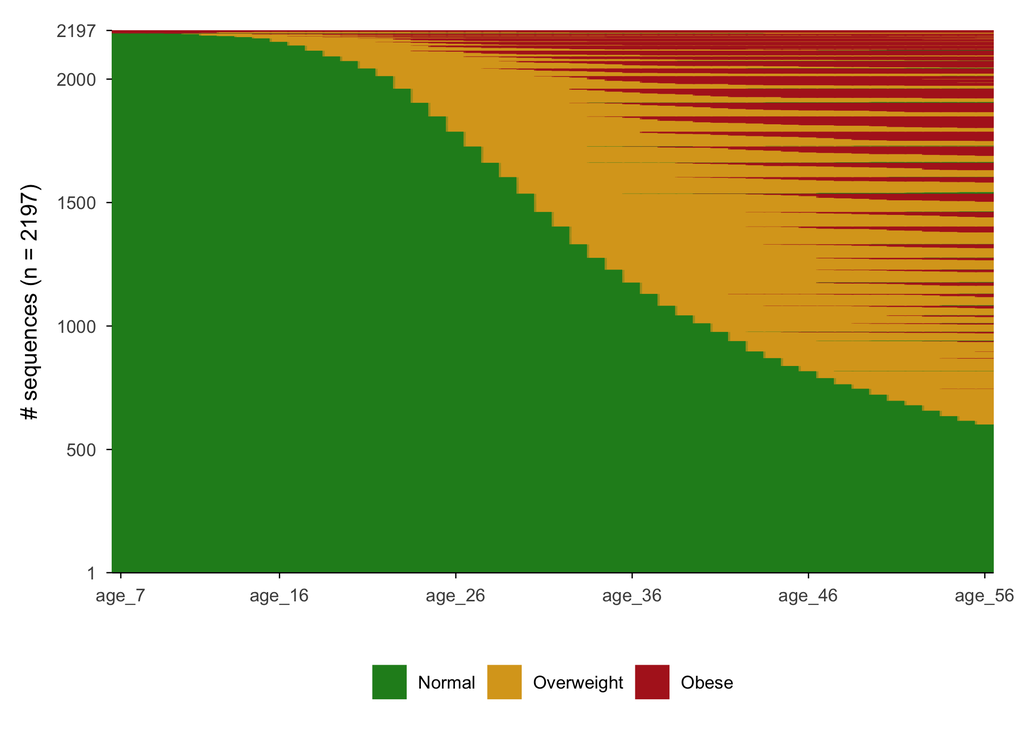

```r
ggseqiplot(bmi_seq, sortv = "from.start")
```

Figure S 4: Sequence index plots of BMI category trajectories stratified by a 2-cluster solution from hierarchical clustering with optimal matching distances.

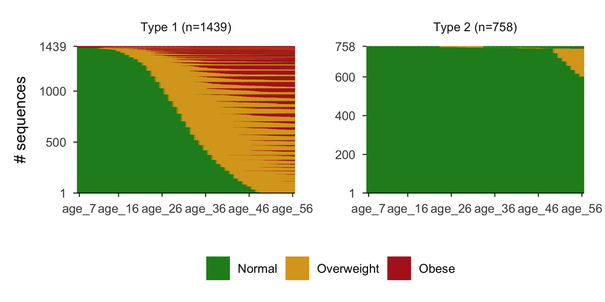

```r
# # 2 Clusters
cl1.2 <- cutree(clusters, k = 2)
cl1.2fac <- factor(cl1.2, labels = paste("Type", 1:2))
# seqIplot(bmi_seq, group = cl1.2fac, sortv = "from.start")

ggseqiplot(bmi_seq, group = cl1.2fac, sortv = "from.start")
```

Figure S 5: Sequence index plots of BMI category trajectories stratified by a 3-cluster solution, identifying Normal BMI, Normal-to-Overweight, and Overweight-to-Obese trajectory groups.

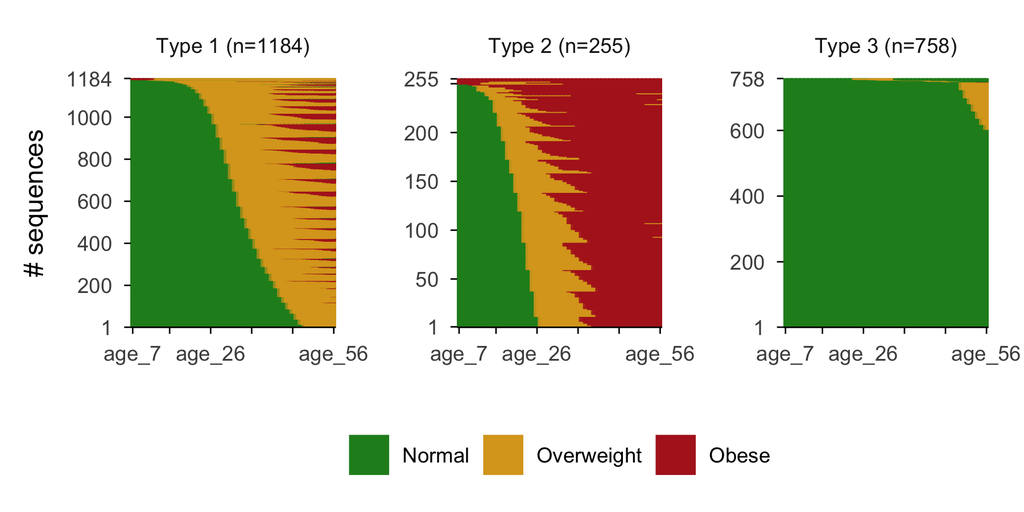

```r
# 3 Clusters
cl1.3 <- cutree(clusters, k = 3)
cl1.3fac <- factor(cl1.3, labels = paste("Type", 1:3))
# seqIplot(bmi_seq, group = cl1.3fac, sortv = "from.start")

ggseqiplot(bmi_seq, group = cl1.3fac, sortv = "from.start")
```

Figure S 6: Sequence index plots of BMI category trajectories stratified by a 4-cluster solution from hierarchical clustering.

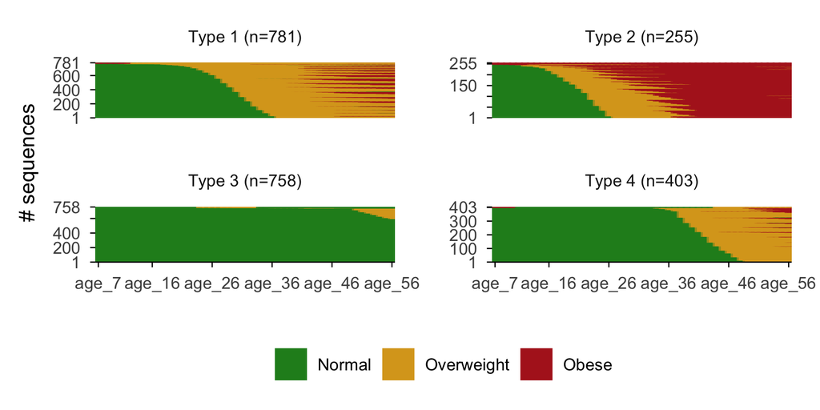

```r
# # 4 Clusters
cl1.4 <- cutree(clusters, k = 4)
cl1.4fac <- factor(cl1.4, labels = paste("Type", 1:4))
# seqIplot(bmi_seq, group = cl1.4fac, sortv = "from.start")

ggseqiplot(bmi_seq, group = cl1.4fac, sortv = "from.start")
```

Figure S 7: Sequence index plots of BMI category trajectories stratified by a 5-cluster solution from hierarchical clustering.

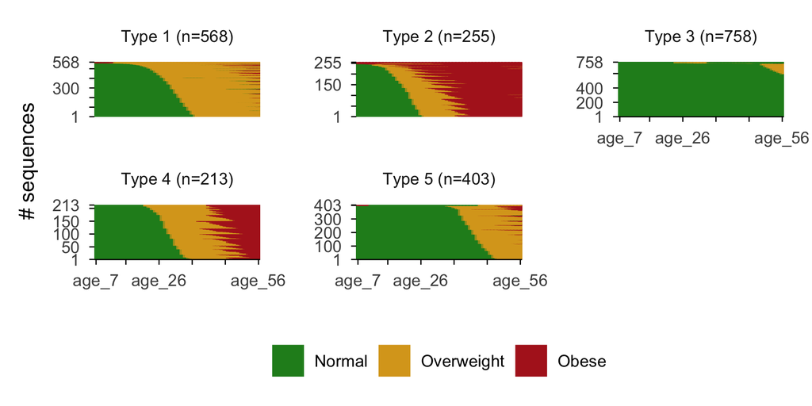

```r
# 5 Clusters
cl1.5 <- cutree(clusters, k = 5)
cl1.5fac <- factor(cl1.5, labels = paste("Type", 1:5))
# seqIplot(bmi_seq, group = cl1.5fac, sortv = "from.start")

ggseqiplot(bmi_seq, group = cl1.5fac, sortv = "from.start")
```

Figure S 8: Sequence index plots of BMI category trajectories stratified by a 6-cluster solution from hierarchical clustering.

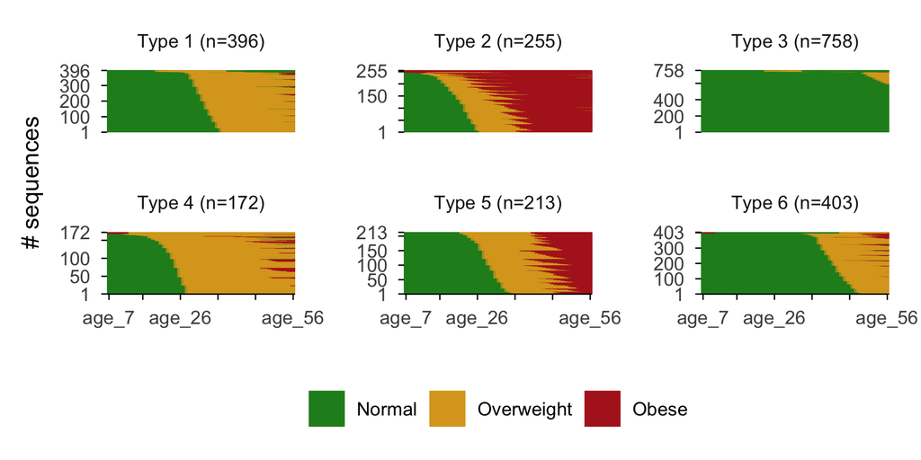

```r
# 6 Clusters
cl1.6 <- cutree(clusters, k = 6)
cl1.6fac <- factor(cl1.6, labels = paste("Type", 1:6))
# seqIplot(bmi_seq, group = cl1.6fac, sortv = "from.start",with.legend = FALSE)

ggseqiplot(bmi_seq, group = cl1.6fac, sortv = "from.start")
```

Figure S 9: Cluster quality metrics (ASW, Calinski-Harabasz, Hubert’s Gamma, Point Biserial Correlation, and R-squared) across 2- to 10-cluster solutions to guide selection of the number of BMI trajectory groups.

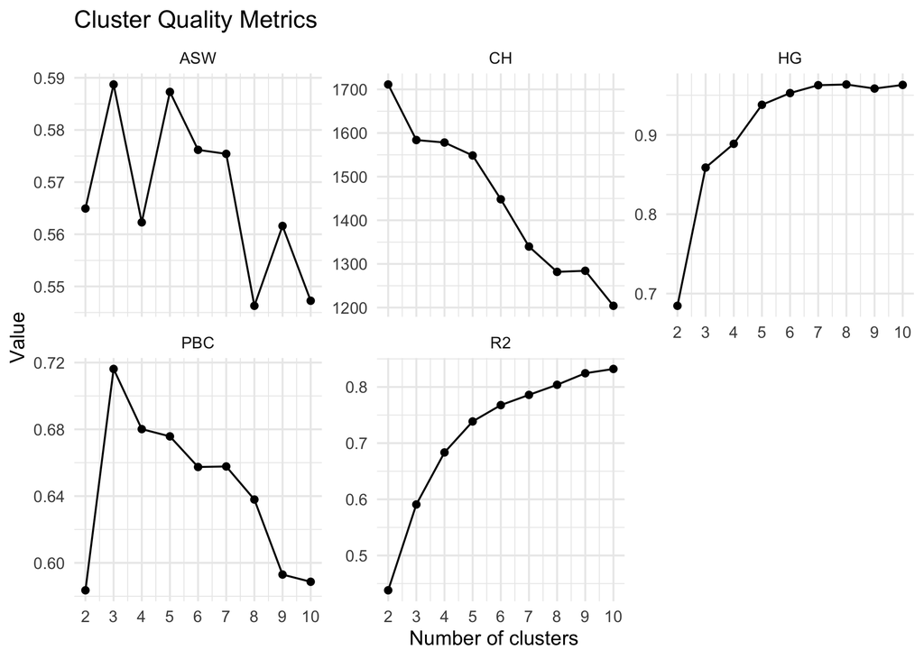

```r
library(WeightedCluster)

# Create a named list of clustering results
cluster_list <- setNames(lapply(2:10, function(k) cutree(clusters, k = k)), 2:10)

# Apply wcClusterQuality and extract key metrics
cluster_metrics <- map_dfr(names(cluster_list), function(k) {
  res <- wcClusterQuality(dist.om1, cluster_list[[k]])
  tibble(
    k = as.integer(k),
    ASW = res$stats["ASW"],
    CH = res$stats["CH"],
    R2 = res$stats["R2"],
    PBC = res$stats["PBC"],
    HG = res$stats["HG"]
  )
})

# Reshape for plotting
long_metrics <- cluster_metrics %>%
  pivot_longer(-k, names_to = "metric", values_to = "value")

# Plot
ggplot(long_metrics, aes(x = k, y = value)) +
  geom_line() +
  geom_point() +
  scale_x_continuous(breaks = 2:10) +
  facet_wrap(~ metric, scales = "free_y") +
  labs(x = "Number of clusters", y = "Value", title = "Cluster Quality Metrics") +
  theme_minimal()
```

Criteria for determining the number of clusters:

- ASW (Average Silhouette Width): Measures how similar each observation is to its own cluster compared to other clusters; values closer to 1 indicate better clustering.
- CH (Calinski-Harabasz Index / Pseudo F Statistic): Ratio of between-cluster variance to within-cluster variance based on the distance matrix.; higher values suggest more distinct clusters.
- HG (Hubert’s Gamma): Measures the correlation between the distances in the data and a binary matrix indicating whether points are in the same cluster (0) or not (1); values closer to 1 reflect stronger clustering structure.
- PBC (Point Biserial Correlation): Measures correlation between the pairwise distances and a binary cluster membership indicator (same cluster vs. different cluster); higher is better.
- R2 (Explained Discrepancy): Indicates the proportion of total variation explained by the clustering; values near 1 are ideal.

```r
# Merge the 5-cluster variable (main model) back into the main dataset for regression analysis.
# Clusters are ordered by exposure, from no excess weight to early-onset obesity, so that the
# reference is the Normal BMI cluster and the order does not depend on the estimates.
df.sequence.pred <- df.sequence %>%
  select(ncdsid) %>%
  cbind(cl1.5) %>%
  rename(TrajectoryClass = cl1.5) %>%
  mutate(TrajectoryClass = factor(TrajectoryClass,
                                  levels = c(3, 5, 1, 4, 2),
                                  labels = c(
                                    "Normal BMI (reference)",
                                    "Late-onset overweight",
                                    "Early-onset overweight",
                                    "Overweight to obese",
                                    "Early-onset obesity"
                                  ))) %>%
  right_join(df.model, by = "ncdsid")

bmi_var <- "TrajectoryClass"
outcomes <- c("loghsCRP")

model.sequence <- map(outcomes, function(outcome) {
  all_covs <- c(bmi_var, covs)
  formula <- reformulate(all_covs, response = outcome)

  df.sequence.pred %>%
    select(all_of(c(outcome, all_covs))) %>%
    lm(formula, data = .)
})

saveRDS(model.sequence, file = here("Data", "Models", "model.sequence.rds"))
```

```r
# Sensitivity analysis: the 3-cluster solution.
# Its Normal-Overweight cluster is the union of the three middle clusters above.
df.sequence.pred.3cl <- df.sequence %>%
  select(ncdsid) %>%
  cbind(cl1.3) %>%
  rename(TrajectoryClass = cl1.3) %>%
  mutate(TrajectoryClass = factor(TrajectoryClass,
                                  levels = c(3, 1, 2),
                                  labels = c(
                                    "Normal BMI", "Normal-Overweight", "Overweight-Obese"
                                  ))) %>%
  right_join(df.model, by = "ncdsid")

model.sequence.3cl <- map(outcomes, function(outcome) {
  all_covs <- c(bmi_var, covs)
  formula <- reformulate(all_covs, response = outcome)

  df.sequence.pred.3cl %>%
    select(all_of(c(outcome, all_covs))) %>%
    lm(formula, data = .)
})

saveRDS(model.sequence.3cl, file = here("Data", "Models", "model.sequence.3cl.rds"))
```

```r
model.sequence %>%
  .[[1]] %>%
  tbl_regression(
    label = list(
      TrajectoryClass ~ "Sequence Class",
      sex ~ "Sex",
      sweep10_age ~ "Age at hsCRP measurement (years)",
      educ_qual ~ "Educational qualification",
      father_bmi ~ "Father's BMI",
      mother_bmi ~ "Mother's BMI",
      n646 ~ "Birthweight",
      n607 ~ "Persons per room",
      n2383 ~ "Father's occupation"
    )
  ) %>%
  add_significance_stars(hide_ci = FALSE) %>%
  bold_p() %>%
  bold_labels()
```

Table S 11: Adjusted linear regression of log(hsCRP) on 5-cluster BMI sequence membership, with the Normal BMI cluster as the reference group.

| **Characteristic** | **Beta**<sup>1</sup> | **SE** | **95% CI** |
| --- | --- | --- | --- |
| Sequence Class |  |  |  |
| Normal BMI (reference) | — | — | — |
| Late-onset overweight | 0.48*** | 0.059 | 0.36, 0.59 |
| Early-onset overweight | 0.34*** | 0.056 | 0.23, 0.45 |
| Overweight to obese | 0.64*** | 0.075 | 0.50, 0.79 |
| Early-onset obesity | 0.78*** | 0.073 | 0.64, 0.93 |
| Sex |  |  |  |
| Female | — | — | — |
| Male | -0.23*** | 0.043 | -0.32, -0.15 |
| Age at hsCRP measurement (years) | 0.01 | 0.043 | -0.07, 0.10 |
| Educational qualification |  |  |  |
| No Qualifications | — | — | — |
| GCSEs or Equivalent | -0.19** | 0.064 | -0.32, -0.07 |
| A Levels or Equivalent | -0.22* | 0.087 | -0.39, -0.05 |
| Degree or Higher | -0.33*** | 0.069 | -0.47, -0.20 |
| Father's BMI | -0.01 | 0.007 | -0.02, 0.01 |
| Mother's BMI | 0.01 | 0.006 | 0.00, 0.02 |
| Birthweight |  |  |  |
| Low | — | — | — |
| Normal | -0.09 | 0.121 | -0.33, 0.15 |
| High | -0.14 | 0.122 | -0.38, 0.10 |
| Persons per room |  |  |  |
| Up to 1 | — | — | — |
| Over 1 to 1.5 | 0.02 | 0.048 | -0.07, 0.12 |
| Over 1.5 to 2 | 0.07 | 0.075 | -0.08, 0.21 |
| Over 2 | 0.20 | 0.147 | -0.09, 0.49 |
| Father's occupation |  |  |  |
| Employed | — | — | — |
| Unemployed, sick, retired, or other | 0.02 | 0.110 | -0.20, 0.23 |
| No male present | 0.01 | 0.102 | -0.19, 0.21 |

Abbreviations: CI = Confidence Interval, SE = Standard Error  
<sup>1</sup> *p<0.05; **p<0.01; ***p<0.001

# 8 Latent Class Trajectory Modeling

Latent class trajectory modeling refers to a family of model-based approaches that identify unobserved subgroups of individuals following similar exposure trajectories over time using finite mixture models.<sup>14,15</sup> The family shares its latent class structure with latent class analysis, but the indicators are repeated continuous measurements rather than categorical items, so classes are defined by the shape of the trajectory over age. Within the family, latent class growth analysis assumes all individuals in a class follow the same trajectory, whereas growth mixture models allow individual variation around the class trajectory through random effects.<sup>15</sup> These models estimate class-specific trajectory shapes and assign individuals probabilistically to latent trajectory classes. Estimation is typically conducted using maximum likelihood, and distal outcomes assessed using a range of approaches.<sup>16,17</sup>

To relate trajectory class membership to inflammation, two approaches are employed. First, a naive 3-step method assigns individuals to their most likely class and enters this assignment directly as a categorical predictor of log(hsCRP) (Table S 13). This approach ignores classification uncertainty, potentially biasing effect estimates toward zero. Second, a maximum likelihood (ML) 3-step method is implemented manually based on Vermunt 2017, incorporating the posterior class probability matrix and the classification error matrix to account for misclassification when estimating class-specific means of the covariate-adjusted outcome (Table S 14). The ML approach provides covariate-adjusted contrasts between trajectory classes with correct standard errors.

```r
library(lcmm)

# Define the data for latent class growth modeling, calculating mean BMI within defined age groups and merging with covariates
df.lgm <- df.bmi_prediction %>%
  right_join(df.model, by = "ncdsid") %>%
  mutate(
    age_group = case_when(
      xage > 6  & xage <= 20 ~ 13.5,
      xage > 20 & xage <= 30 ~ 25,
      xage > 30 & xage <= 40 ~ 35,
      xage > 40 & xage <= 50 ~ 45,
      xage > 50 & xage <= 60 ~ 55,
      TRUE ~ NA_real_
    )
  ) %>%
  group_by(ncdsid, age_group) %>%
  summarise(mean_bmi = mean(pred_bmi, na.rm = TRUE)) %>%
  left_join(  # Reattach time-invariant covariates
    df.model %>%
      select(ncdsid, loghsCRP, all_of(covs)) %>%
      mutate(n607 = as_factor(n607)) %>%
      zap_label(),
    by = "ncdsid"
  ) %>%
  mutate(ncdsid = ncdsid %>%
           str_extract("\\d+") %>%
           as.numeric()) %>%
  ungroup() %>%
  as.data.frame()

# Natural spline basis for age used by the spline growth models, with two internal knots at the tertiles of age (25 and 45) and boundary knots at the youngest and oldest age group
# Stored as fixed columns so knots do not get recomputed if new data is passed to predictY()
age_knots <- quantile(df.lgm$age_group, probs = c(1/3, 2/3))
age_basis <- splines::ns(df.lgm$age_group, knots = age_knots, Boundary.knots = range(df.lgm$age_group))

df.lgm <- df.lgm %>%
  bind_cols(as.data.frame(unclass(age_basis)) %>% setNames(paste0("age_ns", 1:ncol(age_basis))))
```

```r
set.seed(1234)

# Fit latent class growth models with 1 to 6 classes, using a linear specification for age and allowing for class-specific trajectories

# gmmd.bmi.cont.1.lin <- lcmm::hlme(fixed = mean_bmi ~ 1 + age_group ,
#            random = ~1 + age_group,
#            subject = "ncdsid",
#            ng = 1,
#            idiag = FALSE,
#            data = df.lgm,
#            verbose=F)

# gmmd.bmi.cont.2.lin <- lcmm::hlme(fixed = mean_bmi ~ 1 + age_group,
#            mixture = ~ 1 + age_group,
#            random = ~1 + age_group,
#            subject = "ncdsid",
#            ng = 2,
#            nwg = T,
#            idiag = FALSE,
#            data = df.lgm,
#            B=gmmd.bmi.cont.1.lin,
#            verbose=F)

# gmmd.bmi.cont.3.lin <- hlme(fixed = mean_bmi ~ 1 + age_group,
#            mixture = ~ 1 + age_group,
#            random = ~1 + age_group,
#            subject = "ncdsid",
#            ng = 3,
#            nwg = T,
#            idiag = FALSE,
#            data = df.lgm,
#            B=gmmd.bmi.cont.1.lin,
#            verbose=F)

# gmmd.bmi.cont.4.lin <- hlme(fixed = mean_bmi ~ 1 + age_group,
#            mixture = ~ 1 + age_group,
#            random = ~1 + age_group,
#            subject = "ncdsid",
#            ng = 4,
#            nwg = T,
#            idiag = FALSE,
#            data = df.lgm,
#            B=gmmd.bmi.cont.1.lin,
#            verbose=F)

# gmmd.bmi.cont.5.lin <- hlme(fixed = mean_bmi ~ 1 + age_group,
#            mixture = ~ 1 + age_group,
#            random = ~1 + age_group,
#            subject = "ncdsid",
#            ng = 5,
#            nwg = T,
#            idiag = FALSE,
#            data = df.lgm,
#            B=gmmd.bmi.cont.1.lin,
#            verbose=F)

# gmmd.bmi.cont.6.lin <- hlme(fixed = mean_bmi ~ 1 + age_group,
#            mixture = ~ 1 + age_group,
#            random = ~1 + age_group,
#            subject = "ncdsid",
#            ng = 6,
#            nwg = T,
#            idiag = FALSE,
#            data = df.lgm,
#            B=gmmd.bmi.cont.1.lin,
#            verbose=F)

# saveRDS(gmmd.bmi.cont.1.lin,here("Data/gmmd.bmi.cont.1.lin.rds"))
# saveRDS(gmmd.bmi.cont.2.lin,here("Data/gmmd.bmi.cont.2.lin.rds"))
# saveRDS(gmmd.bmi.cont.3.lin,here("Data/gmmd.bmi.cont.3.lin.rds"))
# saveRDS(gmmd.bmi.cont.4.lin,here("Data/gmmd.bmi.cont.4.lin.rds"))
# saveRDS(gmmd.bmi.cont.5.lin,here("Data/gmmd.bmi.cont.5.lin.rds"))
# saveRDS(gmmd.bmi.cont.6.lin,here("Data/gmmd.bmi.cont.6.lin.rds"))

gmmd.bmi.cont.1.lin <- readRDS(here("Data/gmmd.bmi.cont.1.lin.rds"))
gmmd.bmi.cont.2.lin <- readRDS(here("Data/gmmd.bmi.cont.2.lin.rds"))
gmmd.bmi.cont.3.lin <- readRDS(here("Data/gmmd.bmi.cont.3.lin.rds"))
gmmd.bmi.cont.4.lin <- readRDS(here("Data/gmmd.bmi.cont.4.lin.rds"))
gmmd.bmi.cont.5.lin <- readRDS(here("Data/gmmd.bmi.cont.5.lin.rds"))
gmmd.bmi.cont.6.lin <- readRDS(here("Data/gmmd.bmi.cont.6.lin.rds"))

# Create a summary table of model fit statistics for the linear models
gmmfit.cont.lin <- lcmm::summarytable(
  gmmd.bmi.cont.1.lin, gmmd.bmi.cont.2.lin, gmmd.bmi.cont.3.lin, gmmd.bmi.cont.4.lin,
  gmmd.bmi.cont.5.lin, gmmd.bmi.cont.6.lin,
  which = c("G", "loglik", "AIC", "BIC", "SABIC", "entropy", "%class"),
  display = FALSE
) %>%
  as_tibble() %>%
  mutate(entropy = round(entropy, digits = 2),
         Form = "Linear")
```

```r
set.seed(1234)

# Fit latent class growth models with 1 to 6 classes, using a log specification for age and allowing for class-specific trajectories

# gmmd.bmi.cont.1.log <- lcmm::hlme(fixed = mean_bmi ~ 1 + log(age_group) ,
#            random = ~1 + age_group,
#            subject = "ncdsid",
#            ng = 1,
#            idiag = FALSE,
#            data = df.lgm,
#            verbose=F)

# gmmd.bmi.cont.2.log <- lcmm::hlme(fixed = mean_bmi ~ 1 + log(age_group) ,
#            mixture = ~ 1 + log(age_group) ,
#            random = ~1 + age_group,
#            subject = "ncdsid",
#            ng = 2,
#            nwg = T,
#            idiag = FALSE,
#            data = df.lgm,
#            B=gmmd.bmi.cont.1.log,
#            verbose=F)


# gmmd.bmi.cont.3.log <- hlme(fixed = mean_bmi ~ 1 + log(age_group) ,
#            mixture = ~ 1 + log(age_group) ,
#            random = ~1 + age_group,
#            subject = "ncdsid",
#            ng = 3,
#            nwg = T,
#            idiag = FALSE,
#            data = df.lgm,
#            B=gmmd.bmi.cont.1.log,
#            verbose=F)

# gmmd.bmi.cont.4.log <- hlme(fixed = mean_bmi ~ 1 + log(age_group) ,
#            mixture = ~ 1 + log(age_group) ,
#            random = ~1 + age_group,
#            subject = "ncdsid",
#            ng = 4,
#            nwg = T,
#            idiag = FALSE,
#            data = df.lgm,
#            B=gmmd.bmi.cont.1.log,
#            verbose=F)

# gmmd.bmi.cont.5.log <- hlme(fixed = mean_bmi ~ 1 + log(age_group) ,
#            mixture = ~ 1 + log(age_group) ,
#            random = ~1 + age_group,
#            subject = "ncdsid",
#            ng = 5,
#            nwg = T,
#            idiag = FALSE,
#            data = df.lgm,
#            B=gmmd.bmi.cont.1.log,
#            verbose=F)

# gmmd.bmi.cont.6.log <- hlme(fixed = mean_bmi ~ 1 + log(age_group) ,
#            mixture = ~ 1 + log(age_group) ,
#            random = ~1 + age_group,
#            subject = "ncdsid",
#            ng = 6,
#            nwg = T,
#            idiag = FALSE,
#            data = df.lgm,
#            B=gmmd.bmi.cont.1.log,
#            verbose=F)

# saveRDS(gmmd.bmi.cont.1.log,here("Data/gmmd.bmi.cont.1.log.rds"))
# saveRDS(gmmd.bmi.cont.2.log,here("Data/gmmd.bmi.cont.2.log.rds"))
# saveRDS(gmmd.bmi.cont.3.log,here("Data/gmmd.bmi.cont.3.log.rds"))
# saveRDS(gmmd.bmi.cont.4.log,here("Data/gmmd.bmi.cont.4.log.rds"))
# saveRDS(gmmd.bmi.cont.5.log,here("Data/gmmd.bmi.cont.5.log.rds"))
# saveRDS(gmmd.bmi.cont.6.log,here("Data/gmmd.bmi.cont.6.log.rds"))

gmmd.bmi.cont.1.log <- readRDS(here("Data/gmmd.bmi.cont.1.log.rds"))
gmmd.bmi.cont.2.log <- readRDS(here("Data/gmmd.bmi.cont.2.log.rds"))
gmmd.bmi.cont.3.log <- readRDS(here("Data/gmmd.bmi.cont.3.log.rds"))
gmmd.bmi.cont.4.log <- readRDS(here("Data/gmmd.bmi.cont.4.log.rds"))
gmmd.bmi.cont.5.log <- readRDS(here("Data/gmmd.bmi.cont.5.log.rds"))
gmmd.bmi.cont.6.log <- readRDS(here("Data/gmmd.bmi.cont.6.log.rds"))

gmmfit.cont.log <- lcmm::summarytable(
  gmmd.bmi.cont.1.log, gmmd.bmi.cont.2.log, gmmd.bmi.cont.3.log,
  gmmd.bmi.cont.4.log, gmmd.bmi.cont.5.log, gmmd.bmi.cont.6.log,
  which = c("G", "loglik", "AIC", "BIC", "SABIC", "entropy", "%class"),
  display = FALSE
) %>%
  as_tibble() %>%
  mutate(entropy = round(entropy, digits = 2),
         Form = "Log")
```

```r
set.seed(1234)

# Fit latent class growth models with 1 to 6 classes, using a natural cubic spline for age in the class-specific mean trajectories (random effects stay linear in age)

# gmmd.bmi.cont.1.spline <- lcmm::hlme(fixed = mean_bmi ~ 1 + age_ns1 + age_ns2 + age_ns3,
#            random = ~1 + age_group,
#            subject = "ncdsid",
#            ng = 1,
#            idiag = FALSE,
#            data = df.lgm,
#            verbose=F)

# gmmd.bmi.cont.2.spline <- lcmm::hlme(fixed = mean_bmi ~ 1 + age_ns1 + age_ns2 + age_ns3,
#            mixture = ~ 1 + age_ns1 + age_ns2 + age_ns3,
#            random = ~1 + age_group,
#            subject = "ncdsid",
#            ng = 2,
#            nwg = T,
#            idiag = FALSE,
#            data = df.lgm,
#            B=gmmd.bmi.cont.1.spline,
#            verbose=F)

# gmmd.bmi.cont.3.spline <- lcmm::hlme(fixed = mean_bmi ~ 1 + age_ns1 + age_ns2 + age_ns3,
#            mixture = ~ 1 + age_ns1 + age_ns2 + age_ns3,
#            random = ~1 + age_group,
#            subject = "ncdsid",
#            ng = 3,
#            nwg = T,
#            idiag = FALSE,
#            data = df.lgm,
#            B=gmmd.bmi.cont.1.spline,
#            verbose=F)

# gmmd.bmi.cont.4.spline <- lcmm::hlme(fixed = mean_bmi ~ 1 + age_ns1 + age_ns2 + age_ns3,
#            mixture = ~ 1 + age_ns1 + age_ns2 + age_ns3,
#            random = ~1 + age_group,
#            subject = "ncdsid",
#            ng = 4,
#            nwg = T,
#            idiag = FALSE,
#            data = df.lgm,
#            B=gmmd.bmi.cont.1.spline,
#            verbose=F)

# gmmd.bmi.cont.5.spline <- lcmm::hlme(fixed = mean_bmi ~ 1 + age_ns1 + age_ns2 + age_ns3,
#            mixture = ~ 1 + age_ns1 + age_ns2 + age_ns3,
#            random = ~1 + age_group,
#            subject = "ncdsid",
#            ng = 5,
#            nwg = T,
#            idiag = FALSE,
#            data = df.lgm,
#            B=gmmd.bmi.cont.1.spline,
#            verbose=F)

# gmmd.bmi.cont.6.spline <- lcmm::hlme(fixed = mean_bmi ~ 1 + age_ns1 + age_ns2 + age_ns3,
#            mixture = ~ 1 + age_ns1 + age_ns2 + age_ns3,
#            random = ~1 + age_group,
#            subject = "ncdsid",
#            ng = 6,
#            nwg = T,
#            idiag = FALSE,
#            data = df.lgm,
#            B=gmmd.bmi.cont.1.spline,
#            verbose=F)


# saveRDS(gmmd.bmi.cont.1.spline,here("Data/gmmd.bmi.cont.1.spline.rds"))
# saveRDS(gmmd.bmi.cont.2.spline,here("Data/gmmd.bmi.cont.2.spline.rds"))
# saveRDS(gmmd.bmi.cont.3.spline,here("Data/gmmd.bmi.cont.3.spline.rds"))
# saveRDS(gmmd.bmi.cont.4.spline,here("Data/gmmd.bmi.cont.4.spline.rds"))
# saveRDS(gmmd.bmi.cont.5.spline,here("Data/gmmd.bmi.cont.5.spline.rds"))
# saveRDS(gmmd.bmi.cont.6.spline,here("Data/gmmd.bmi.cont.6.spline.rds"))

gmmd.bmi.cont.1.spline <- readRDS(here("Data/gmmd.bmi.cont.1.spline.rds"))
gmmd.bmi.cont.2.spline <- readRDS(here("Data/gmmd.bmi.cont.2.spline.rds"))
gmmd.bmi.cont.3.spline <- readRDS(here("Data/gmmd.bmi.cont.3.spline.rds"))
gmmd.bmi.cont.4.spline <- readRDS(here("Data/gmmd.bmi.cont.4.spline.rds"))
gmmd.bmi.cont.5.spline <- readRDS(here("Data/gmmd.bmi.cont.5.spline.rds"))
gmmd.bmi.cont.6.spline <- readRDS(here("Data/gmmd.bmi.cont.6.spline.rds"))

gmmfit.cont.spline <- lcmm::summarytable(
  gmmd.bmi.cont.1.spline, gmmd.bmi.cont.2.spline, gmmd.bmi.cont.3.spline, gmmd.bmi.cont.4.spline,gmmd.bmi.cont.5.spline,gmmd.bmi.cont.6.spline,
  which = c("G", "loglik", "AIC", "BIC", "SABIC", "entropy", "%class"),
  display = FALSE
) %>%
  as_tibble() %>%
  mutate(entropy = round(entropy, digits = 2),
         Form = "Spline")
```

```r
bind_rows(gmmfit.cont.lin, gmmfit.cont.log, gmmfit.cont.spline) %>%
    mutate(across(starts_with("%class"), ~ round(.x, 1))) %>%
    relocate(Form) %>%
    gt(groupname_col = "Form") %>%
    tab_header(title = "Growth Mixture Model Fit Comparison") %>%
    tab_options(
      heading.background.color = "gray",
      heading.title.font.size = px(16),
      heading.title.font.weight = "bold",
      table.font.size = px(12)
    ) %>%
    cols_label(
      G = "Classes",
      loglik = "Log Likelihood",
      entropy = "Entropy",
      BIC = "BIC",
      SABIC = "SABIC"
    ) %>%
    cols_width(
      G ~ px(60)
    ) %>%
    tab_style(
      style = list(
        cell_fill(color = "lightgray"),
        cell_text(weight = "bold")
      ),
      locations = cells_body(
        rows = Form == "Spline" & G == 3
      )
    )
```

Table S 12: Model fit statistics (log-likelihood, AIC, BIC, SABIC, and entropy) for latent class trajectory models with linear, logarithmic, and spline functional forms across varying numbers of classes.

Growth Mixture Model Fit Comparison

| Classes | Log Likelihood | AIC | BIC | SABIC | Entropy | %class1 | %class2 | %class3 | %class4 | %class5 | %class6 |
| --- | --- | --- | --- | --- | --- | --- | --- | --- | --- | --- | --- |
| Linear |  |  |  |  |  |  |  |  |  |  |  |
| 1 | -22976.09 | 45964.17 | 45998.34 | 45979.28 | 1.00 | 100.0 | NA | NA | NA | NA | NA |
| 2 | -22672.56 | 45365.12 | 45422.07 | 45390.30 | 0.60 | 88.5 | 11.5 | NA | NA | NA | NA |
| 3 | -22630.22 | 45288.45 | 45368.18 | 45323.70 | 0.48 | 42.1 | 8.3 | 49.6 | NA | NA | NA |
| 4 | -22619.02 | 45274.05 | 45376.55 | 45319.37 | 0.46 | 27.7 | 36.7 | 5.5 | 30.1 | NA | NA |
| 5 | -22613.49 | 45270.98 | 45396.27 | 45326.37 | 0.56 | 30.2 | 15.5 | 46.3 | 4.8 | 3.2 | NA |
| 6 | -22609.01 | 45270.03 | 45418.10 | 45335.49 | 0.60 | 1.8 | 27.7 | 46.8 | 15.9 | 5.1 | 2.7 |
| Log |  |  |  |  |  |  |  |  |  |  |  |
| 1 | -20067.04 | 40146.07 | 40180.24 | 40161.18 | 1.00 | 100.0 | NA | NA | NA | NA | NA |
| 2 | -19381.17 | 38782.34 | 38839.29 | 38807.52 | 0.86 | 89.1 | 10.9 | NA | NA | NA | NA |
| 3 | -19158.34 | 38344.69 | 38424.42 | 38379.94 | 0.73 | 67.5 | 3.4 | 29.2 | NA | NA | NA |
| 4 | -18456.21 | 36948.42 | 37050.93 | 36993.74 | 0.83 | 64.5 | 28.6 | 3.2 | 3.8 | NA | NA |
| 5 | -18319.92 | 36683.83 | 36809.12 | 36739.22 | 0.81 | 54.7 | 34.2 | 6.3 | 0.7 | 4.1 | NA |
| 6 | -18253.90 | 36559.79 | 36707.86 | 36625.25 | 0.73 | 26.7 | 41.4 | 21.8 | 4.6 | 0.6 | 4.7 |
| Spline |  |  |  |  |  |  |  |  |  |  |  |
| 1 | -20026.04 | 40068.09 | 40113.65 | 40088.23 | 1.00 | 100.0 | NA | NA | NA | NA | NA |
| 2 | -19011.71 | 38051.43 | 38131.15 | 38086.67 | 0.73 | 66.5 | 33.5 | NA | NA | NA | NA |
| 3 | -18156.22 | 36352.44 | 36466.33 | 36402.79 | 0.84 | 70.1 | 12.3 | 17.6 | NA | NA | NA |
| 4 | -17214.87 | 34481.74 | 34629.81 | 34547.20 | 0.88 | 0.3 | 58.7 | 32.4 | 8.6 | NA | NA |
| 5 | -16570.88 | 33205.76 | 33388.00 | 33286.33 | 0.88 | 13.7 | 47.4 | 0.3 | 4.2 | 34.4 | NA |
| 6 | -16245.47 | 32566.95 | 32783.35 | 32662.62 | 0.90 | 43.0 | 37.0 | 11.5 | 0.3 | 0.8 | 7.5 |

```r
bmi_var <- "TrajectoryClass"
outcomes <- c("loghsCRP")

# Run LCTM models
model.lca <- map(outcomes, function(outcome) {
  all_covs <- c(bmi_var, covs)
  formula <- reformulate(all_covs, response = outcome)

gmmd.bmi.cont.3.spline$pprob %>%
  select(ncdsid, class) %>%
  mutate(
    TrajectoryClass = factor(class,
                           levels = c(1, 3, 2),
                           labels = c("Normal BMI",
                                      "Elevated BMI",
                                      "Accelerating BMI"
                                      ))
  ) %>%
  right_join(df.lgm, by = 'ncdsid') %>%
    select(all_of(c("ncdsid", outcome, all_covs))) %>%
    distinct() %>%   # one row per person (df.lgm has one row per age group)
    select(-ncdsid) %>%
    lm(formula, data = .)
})

saveRDS(model.lca, file = here("Data", "Models", "model.LCA.rds"))
```

```r
model.lca %>%
  .[[1]] %>%
  tbl_regression(
    label = list(
      TrajectoryClass ~ "Trajectory Class",
      sex ~ "Sex",
      sweep10_age ~ "Age at hsCRP measurement (years)",
      educ_qual ~ "Educational qualification",
      father_bmi ~ "Father's BMI",
      mother_bmi ~ "Mother's BMI",
      n646 ~ "Birthweight",
      n607 ~ "Persons per room",
      n2383 ~ "Father's occupation"
    )
  ) %>%
  add_significance_stars(hide_ci = FALSE) %>%
  bold_p() %>%
  bold_labels()
```

Table S 13: Adjusted linear regression of log(hsCRP) on 3-class spline LCTM membership using naive modal class assignment (no correction for classification uncertainty).

| **Characteristic** | **Beta**<sup>1</sup> | **SE** | **95% CI** |
| --- | --- | --- | --- |
| Trajectory Class |  |  |  |
| Normal BMI | — | — | — |
| Elevated BMI | 0.11 | 0.057 | 0.00, 0.22 |
| Accelerating BMI | 0.35*** | 0.065 | 0.23, 0.48 |
| Sex |  |  |  |
| Female | — | — | — |
| Male | -0.13** | 0.043 | -0.22, -0.05 |
| Age at hsCRP measurement (years) | 0.00 | 0.045 | -0.09, 0.09 |
| Educational qualification |  |  |  |
| No Qualifications | — | — | — |
| GCSEs or Equivalent | -0.20** | 0.065 | -0.33, -0.08 |
| A Levels or Equivalent | -0.27** | 0.089 | -0.44, -0.09 |
| Degree or Higher | -0.39*** | 0.070 | -0.53, -0.26 |
| Father's BMI | 0.00 | 0.007 | -0.01, 0.02 |
| Mother's BMI | 0.02*** | 0.006 | 0.01, 0.03 |
| Birthweight |  |  |  |
| Low | — | — | — |
| Normal | -0.09 | 0.125 | -0.34, 0.15 |
| High | -0.15 | 0.125 | -0.39, 0.10 |
| Persons per room |  |  |  |
| Up to 1 | — | — | — |
| Over 1 to 1.5 | 0.04 | 0.049 | -0.05, 0.14 |
| Over 1.5 to 2 | 0.10 | 0.077 | -0.05, 0.26 |
| Over 2 | 0.24 | 0.151 | -0.05, 0.54 |
| Father's occupation |  |  |  |
| Employed | — | — | — |
| Unemployed, sick, retired, or other | 0.01 | 0.113 | -0.21, 0.23 |
| No male present | 0.04 | 0.104 | -0.17, 0.24 |

Abbreviations: CI = Confidence Interval, SE = Standard Error  
<sup>1</sup> *p<0.05; **p<0.01; ***p<0.001

```r
# Implementing the ML-3 Step Method Manually to Account for Classification Uncertainty

# Step 1. Join with posterior class probabilities from hlme
distal_var <- "loghsCRP"

df_person <- df.lgm %>%
  select(ncdsid, all_of(distal_var), all_of(covs)) %>%
  distinct()

pp <- gmmd.bmi.cont.3.spline$pprob %>%
  select(ncdsid, class, starts_with("prob"))

# how many classes
Tcl <- length(grep("^prob", names(pp)))
prob_cols <- paste0("prob", 1:Tcl)

analysis_df <- pp %>%
  inner_join(df_person, by = "ncdsid") %>%
  drop_na(!!sym(distal_var))

# posterior matrix tau_it = P(X=t | Y_i)
tau <- as.matrix(analysis_df[, prob_cols])  # N x T
Wobs <- analysis_df$class                   # observed assigned class W_i
N    <- nrow(analysis_df)
Tcl  <- ncol(tau)

# Step 2. Classification error matrix P(W = s | X = t)

# N x T indicator matrix: I(W_i = s)
W_mat <- sapply(1:Tcl, function(s) as.numeric(Wobs == s))  # N x T

R <- matrix(NA_real_, nrow = Tcl, ncol = Tcl,
            dimnames = list(paste0("X", 1:Tcl),
                            paste0("W", 1:Tcl)))

for (t in 1:Tcl) {
  denom_t <- sum(tau[, t])
  for (s in 1:Tcl) {
    numer_ts <- sum(tau[, t] * W_mat[, s])
    R[t, s] <- numer_ts / denom_t
  }
}

# R
# rowSums(R)  # should be ~ 1 for each t

pi_hat <- colMeans(tau)   # P(X=t)

# Step 3. Covariate adjustment by residualizing the distal outcome

form_cov <- reformulate(covs, response = distal_var)

lm_cov <- lm(form_cov, data = analysis_df)

analysis_df$Ztilde <- resid(lm_cov)   # covariate adjusted residuals

# Vectors for ML step
Ztilde <- analysis_df$Ztilde
Wobs   <- analysis_df$class

# Step 4. Define the ML 3-step likelihood

logLik_ml3 <- function(par, Ztilde, Wobs, pi_hat, R) {
  T <- length(pi_hat)
  mu <- par[1:T]
  log_sigma <- par[T + 1]
  sigma <- exp(log_sigma)

  N <- length(Ztilde)
  ll <- 0

  for (i in 1:N) {
    s <- Wobs[i]  # observed assigned class (1..T)
    # density of Ztilde_i under each class t (this is the normal distribution assumption)
    dens_vec <- dnorm(Ztilde[i], mean = mu, sd = sigma, log = FALSE)
    # contribution for each class t
    comp <- pi_hat * dens_vec * R[, s]
    p_i <- sum(comp)
    if (!is.finite(p_i) || p_i <= .Machine$double.eps) {
      p_i <- .Machine$double.eps
    }
    ll <- ll + log(p_i)
  }

  return(-ll)   # negative log likelihood
}

# Step 5. Optimize the ML 3-step likelihood

mu0 <- tapply(analysis_df$Ztilde, analysis_df$class, mean)
log_sigma0 <- log(sd(analysis_df$Ztilde))

par0 <- c(mu0, log_sigma0)

fit_ml3 <- optim(
  par    = par0,
  fn     = logLik_ml3,
  Ztilde = Ztilde,
  Wobs   = Wobs,
  pi_hat = pi_hat,
  R      = R,
  method = "BFGS",
  hessian = TRUE
)

# fit_ml3$convergence  # should be 0 if successful

par_hat <- fit_ml3$par
Tcl <- length(pi_hat)

mu_hat      <- par_hat[1:Tcl]          # class specific adjusted means
log_sigma_h <- par_hat[Tcl + 1]
sigma_hat   <- exp(log_sigma_h)

vcov_par <- solve(fit_ml3$hessian)
se_par   <- sqrt(diag(vcov_par))

se_mu        <- se_par[1:Tcl]
se_log_sigma <- se_par[Tcl + 1]
se_sigma     <- sigma_hat * se_log_sigma

results_mu <- data.frame(
  class   = 1:Tcl,
  mu_hat  = mu_hat,
  se_mu   = se_mu,
  z_value = mu_hat / se_mu,
  p_value = 2 * pnorm(abs(mu_hat / se_mu), lower.tail = FALSE)
)
# results_mu


# Step 6. Optional: pairwise contrasts vs class 1

get_ml3_contrasts <- function(par_hat, vcov_par, ref = 1) {
  Tcl <- length(par_hat) - 1  # last parameter is log_sigma
  results <- list()

  for (t in seq_len(Tcl)) {
    if (t == ref) next

    # contrast vector: mu_t - mu_ref
    c_vec <- rep(0, length(par_hat))
    c_vec[t]   <- 1
    c_vec[ref] <- -1

    # point estimate
    est <- sum(c_vec * par_hat)

    # SE
    se  <- sqrt(t(c_vec) %*% vcov_par %*% c_vec)

    # z, p, CI
    z_val <- est / se
    p_val <- 2 * pnorm(abs(z_val), lower.tail = FALSE)
    ci_lo <- est - 1.96 * se
    ci_hi <- est + 1.96 * se

    results[[length(results) + 1]] <- data.frame(
      contrast = paste0("class", t, " - class", ref),
      estimate = est,
      std_error = se,
      z_value = z_val,
      p_value = p_val,
      CI_lower = ci_lo,
      CI_upper = ci_hi
    )
  }

  bind_rows(results)
}

contrasts_tbl <- get_ml3_contrasts(par_hat, vcov_par, ref = 1)

# Get labeled class contrasts
contrasts_tbl$contrast <- contrasts_tbl$contrast %>%
    dplyr::recode(
      "class3 - class1" = "Elevated BMI",
      "class2 - class1" = "Accelerating BMI"
    )
contrasts_tbl <- contrasts_tbl %>%
  arrange(match(contrast, c("Elevated BMI", "Accelerating BMI")))

saveRDS(contrasts_tbl, file = here("Data", "Models", "model.LCA.ML.rds"))
```

```r
contrasts_tbl %>%
    select(-z_value) %>%
    gt() %>%
    tab_header(
      title = "Latent Class Contrasts for log(hsCRP)",
      subtitle = "Reference: Normal BMI Trajectory"
    ) %>%
    cols_label(
      contrast = "Comparison",
      estimate = "β",
      std_error = "SE",
      p_value = "p",
      CI_lower = "95% CI LL",
      CI_upper = "95% CI UL"
    ) %>%
    fmt_number(
      columns = c(estimate, std_error, CI_lower, CI_upper),
      decimals = 3
    ) %>%
    fmt(
      columns = p_value,
      fns = function(x) ifelse(x < 0.001, "<0.001", sprintf("%.3f", x))
    ) %>%
    tab_style(
      style = cell_text(weight = "bold"),
      locations = cells_body(
        columns = p_value,
        rows = p_value < 0.05
      )
    ) %>%
    tab_footnote(
      footnote = "Estimates adjusted for sex, age at hsCRP measurement, educational qualification, parental BMI, birthweight, persons per room, and father's occupation. Classification uncertainty accounted for using the ML 3-step approach."
    ) %>%
    tab_options(
      table.font.size = px(12),
      heading.title.font.size = px(16),
      heading.title.font.weight = "bold"
    )
```

Table S 14: Covariate-adjusted pairwise contrasts of log(hsCRP) between latent trajectory classes using the ML 3-step method, which accounts for classification uncertainty via the posterior probability matrix.

Latent Class Contrasts for log(hsCRP)

Reference: Normal BMI Trajectory

| Comparison | β | SE | p | 95% CI LL | 95% CI UL |
| --- | --- | --- | --- | --- | --- |
| Elevated BMI | 0.137 | 0.065 | 0.034 | 0.011 | 0.264 |
| Accelerating BMI | 0.400 | 0.074 | <0.001 | 0.254 | 0.545 |

Estimates adjusted for sex, age at hsCRP measurement, educational qualification, parental BMI, birthweight, persons per room, and father's occupation. Classification uncertainty accounted for using the ML 3-step approach.